# Stock Mining - Alpha Prediction

[figure not shown]

#### Alpha is the measure fundamental quandary for investors of how get the highest return possible for the least amount of risk. It is a measurable way to determine whether a manager's skill has added value to a fund on a risk-adjusted basis.

### Predicting the alpha signal using microblogging data

##### Importing Libraries:

```python
import numpy as np
import pandas as pd
import copy

#Imputers
from sklearn.impute import SimpleImputer
from sklearn.preprocessing import StandardScaler

#Split
from sklearn.model_selection import train_test_split

#Visualization plot
import matplotlib.pyplot as plt
import seaborn as sns
%matplotlib inline
from wordcloud import WordCloud

from IPython.display import Image
from IPython.core.display import HTML
from datetime import datetime

#Text
import spacy
nlp = spacy.load('en_core_web_sm')
import re
import textblob
from textblob import TextBlob
import random
random.seed(123)
#ignore warnings
import warnings
warnings.filterwarnings('ignore')
from nltk.stem.snowball import SnowballStemmer

from contractions import CONTRACTION_MAP
import unicodedata

#Model
from sklearn.linear_model import LogisticRegression
from sklearn.naive_bayes import MultinomialNB

from sklearn.metrics import confusion_matrix,f1_score
from sklearn.metrics import classification_report
```

```python
#This for displaying the whole content of a dataframe:
pd.options.display.max_colwidth = 1000
```

## Analysing Json Text Data:

##### Reading the Train and Test Json file and converting it into a data frame.

```python
trainData_df = pd.read_json('train_data-1573118738755.json',orient='columns')
trainData_df = pd.read_json( (trainData_df['records']).to_json(),orient='index')
```

```python
testData_df = pd.read_json('test_data.json',orient='columns')
testData_df = pd.read_json((testData_df['records']).to_json(),orient='index')
```

```python
trainData_df.head()
```

|  | sentiment_score | stocktwit_tweet | ticker | timestamp |
| --- | --- | --- | --- | --- |
| 0 | 3 | $AMD going up but hesitating however chart is very stable and going upward | $AMD | 2018-09-19 18:38:28 |
| 1 | 3 | @inforlong @MariaGascon Despite\nChina trade war $CAT held very well 👍 | $CAT | 2018-10-09 03:51:06 |
| 2 | 2 | $AVGO WTF? | $AVGO | 2018-07-12 13:35:32 |
| 3 | 2 | $PH\n New Insider Filing On: \n MULLER KLAUS PETER\nTransaction Code: \n http://www.filingscanner.com/Alerts/PH.php | $PH | 2018-07-19 03:32:50 |
| 4 | 3 | $FB if it bounces tommorrow do the right thing and GTFO | $FB | 2018-08-23 19:07:54 |

```python
testData_df.head()
```

|  | stocktwit_tweet | ticker | timestamp |
| --- | --- | --- | --- |
| 0 | $CELG nothing to be exited about | $CELG | 2018-10-25 14:26:16 |
| 1 | $AMD yall exhaust your buyer on first green candle,,,, byeeeeee | $AMD | 2018-07-13 13:50:39 |
| 2 | $AMD day traders day. | $AMD | 2018-09-25 19:10:54 |
| 3 | $CBS https://tenor.com/wLB8.gif | $CBS | 2018-07-27 22:45:48 |
| 4 | $MU weak price action so far today. Don’t be afraid to go short, it’s gonna break support and free fall soon | $MU | 2018-07-31 14:59:06 |

##### Checking the Data types of the features in both Train & Test data

```python
trainData_df.dtypes
```

```
sentiment_score             int64
stocktwit_tweet            object
ticker                     object
timestamp          datetime64[ns]
dtype: object
```

```python
testData_df.dtypes
```

```
stocktwit_tweet            object
ticker                     object
timestamp          datetime64[ns]
dtype: object
```

```python
# Changing the data type of Train features to its respective form.
trainData_df['stocktwit_tweet'] = trainData_df['stocktwit_tweet'].astype('category')
trainData_df['ticker']          = trainData_df['ticker'].astype('category')

# Changing the data type of Test features to its respective form.
testData_df['stocktwit_tweet'] = testData_df['stocktwit_tweet'].astype('category')
testData_df['ticker']          = testData_df['ticker'].astype('category')
```

```python
print("Shape of Train data is = ", trainData_df.shape)
print("Shape of test data is  = ",  testData_df.shape)
```

```
Shape of Train data is =  (1039131, 4)
Shape of test data is  =  (265022, 3)
```

### Feature Engineering:

##### Creating new attribute for both Train and Test dataframe:

```python
# Separating Month attribute from timestamp.
trainData_df['Month']  = trainData_df['timestamp'].dt.month_name(locale = 'English')
testData_df ['Month']  = testData_df ['timestamp'].dt.month_name(locale = 'English')

# Changing the data type
trainData_df['Month'] = trainData_df['Month'].astype('category')
testData_df ['Month'] = testData_df ['Month'].astype('category')
```

```python
# Separating Day attribute from timestamp.
trainData_df['Weekday']  = trainData_df['timestamp'].dt.weekday_name
testData_df ['Weekday']  = testData_df ['timestamp'].dt.weekday_name

# Changing the data type
trainData_df['Weekday'] = trainData_df['Weekday'].astype('category')
testData_df ['Weekday'] = testData_df ['Weekday'].astype('category')
```

```python
# Sorting data according to timestamp:
trainData_df = trainData_df.sort_values(by=['timestamp'])
testData_df  = testData_df.sort_values (by=['timestamp'])
```

##### Creating Weekly data:

```python
weeklyData = pd.DataFrame(pd.Series(trainData_df.Weekday.value_counts()))
```

```python
weeklyData = weeklyData.reset_index()
weeklyData.head()
```

|  | index | Weekday |
| --- | --- | --- |
| 0 | Thursday | 220231 |
| 1 | Wednesday | 218214 |
| 2 | Tuesday | 208086 |
| 3 | Friday | 170646 |
| 4 | Monday | 166159 |

```python
weeklyData = weeklyData.rename(columns  = {"index": "Day", "Weekday":"ReviewCount"})
```

### Visualizing the spread of data per Month:

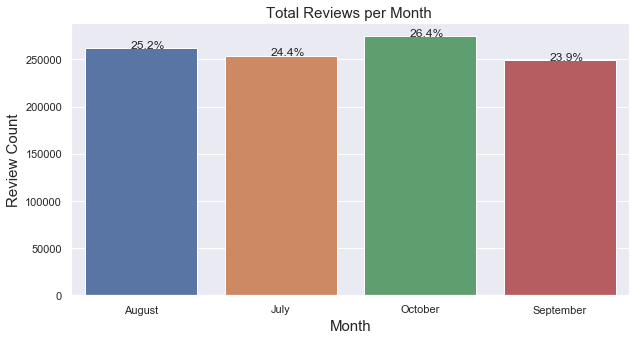

```python
total = trainData_df.Month.value_counts().sum()
sns.set(rc={'figure.figsize':(10,5)})
plot = sns.countplot(x="Month",data=trainData_df)
plt.title("Total Reviews per Month ",fontsize=15)
plt.xlabel("Month",fontsize=15)
plt.ylabel("Review Count",fontsize=15)
for p in plot.patches:
    plot.annotate('{:.1f}%'.format(100*p.get_height()/total), (p.get_x()+0.325, p.get_height()+5))
```

###### The total number of Tweets obtained for each month are nearly equal.

### Visualizing the spread of data as per Week

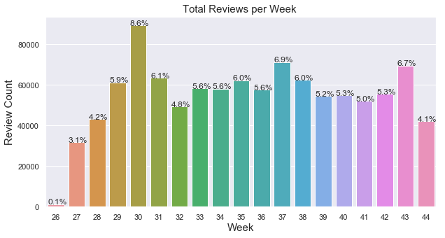

```python
#Total number of data in the Json file.
total = trainData_df.Month.value_counts().sum()
sns.set(rc={'figure.figsize':(10,5)})
plot = sns.countplot(x=trainData_df['timestamp'].dt.week ,data=trainData_df)
plt.title("Total Reviews per Week ",fontsize=15)
plt.xlabel("Week",fontsize=15)
plt.ylabel("Review Count",fontsize=15)
for p in plot.patches:
    plot.annotate('{:.1f}%'.format(100*p.get_height()/total), (p.get_x(), p.get_height()+10))
```

### Visualizing the spread of data in Days

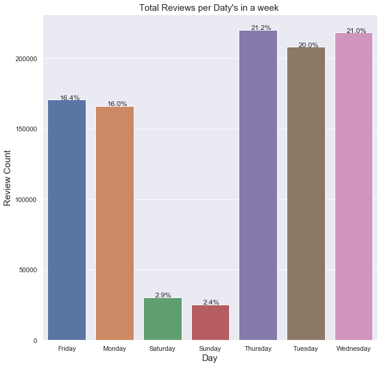

```python
total = trainData_df.Month.value_counts().sum()
sns.set(rc={'figure.figsize':(10,10)})
plot = sns.barplot(x="Day",y='ReviewCount',data=weeklyData)
plt.title("Total Reviews per Daty's in a week ",fontsize=15)
plt.xlabel("Day",fontsize=15)
plt.ylabel("Review Count",fontsize=15)
for p in plot.patches:
    plot.annotate('{:.1f}%'.format(100*p.get_height()/total), (p.get_x()+0.25, p.get_height()+10))
```

#### Most of the reviews are given on the Mid of the week(Tuesday,Wednesday,Thursday) where the market will be more active. The remaing ##### weekdays have significant review counts when compared to the weekends where market will be closed

### Checking the Polarity of all the tweets:

```python
polarity_df = trainData_df[['stocktwit_tweet']]
```

```python
trainData_df['polarity'] = trainData_df['stocktwit_tweet'].map(lambda text: TextBlob(text).sentiment.polarity)
testData_df['polarity'] = testData_df['stocktwit_tweet'].map(lambda text: TextBlob(text).sentiment.polarity)
testData_df.head()
```

|  | stocktwit_tweet | ticker | timestamp | Month | Weekday | polarity |
| --- | --- | --- | --- | --- | --- | --- |
| 242499 | #STAAnalystAlert for $TDG : Jefferies Maintains with a rating of Hold setting target price at USD 350.00. Our own verdict is Buy http://www.stocktargetadvisor.com/toprating | $TDG | 2018-07-01 00:01:24 | July | Sunday | 0.600000 |
| 86410 | $SNPS short ratio is 2.17 at 2018-06-15 and short % to float is 1.42% http://sunshineavenue.com/stock/SNPS/ via @sunshineave | $SNPS | 2018-07-01 00:09:36 | July | Sunday | 0.000000 |
| 15537 | $NFLX price squeezing,perfect place for an option straddle near the supporting trend | $NFLX | 2018-07-01 00:12:58 | July | Sunday | 0.175000 |
| 206362 | Short volume percent for $URI was 35.42% on 06-28-18 and 20 day rank was ~20th percentile https://volumebot.com/?s=URI | $URI | 2018-07-01 00:30:01 | July | Sunday | -0.266667 |
| 263423 | $K has a better Return On Equity than the industry average of 40.97%. https://www.chartmill.com/analyze.php?utm_source=stocktwits&amp;utm_medium=FA&amp;utm_content=PROFITABILITY&amp;utm_campaign=socia… | $K | 2018-07-01 00:32:03 | July | Sunday | 0.175000 |

#### 5 Random Positive Tweets:

```python
print('5 random reviews with the highest positive sentiment polarity: \n')
cl = trainData_df.loc[trainData_df.polarity == 1, ['stocktwit_tweet']].sample(5).values
for c in cl:
    print(c[0])
```

```
5 random reviews with the highest positive sentiment polarity:

@Dunkar yes CBD will fly way B4 THC (pot)! CBD is going mainstream!  Soon you will see LeBron J as a spoke person for CBD drinks if $KO in!
$ALB great quarter, beat on both rev and eps, increased guidance as well !
I bet in Jan $amzn reports best Christmas/4th qtr numbers ever
$GS dipping end of day but still an awesome day
$AMD
I warned you all to load up before ER dropped.
Made a wonderful 5$ a share since and still holding.
Will continue to hold.
```

#### 5 Random Negative Tweets:

```python
cl = trainData_df.loc[trainData_df.polarity == -1, ['stocktwit_tweet']].sample(5).values
for c in cl:
    print(c[0])
```

```
$AMD holy green!!!!!!! Shorts running in fear!!!
$BKNG worst stock ever
$AMZN Powell has to be the worst apprentice ever!  Fire him already and get him off the show!
$AMZN Remember Jefferies and Stifel Nicholas upgraded this to buy with a $2500 Price Target!!!! What a bunch of morons!!!
$AMZN This is why we need to get out of EVIL CHINA:
https://sg.news.yahoo.com/china-used-tiny-chips-us-computers-steal-secrets-135924842.html
BASTARDS!
```

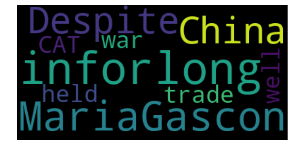

```python
wordcloud = WordCloud().generate(trainData_df.stocktwit_tweet[1])

# Display the generated image:
plt.imshow(wordcloud, interpolation='bilinear')
plt.axis("off")
plt.show()
```

### Text Preprocessing:

```python
# taking a deep copy of Train and Test data for preprocessing.
preprocess_Train = copy.deepcopy(trainData_df)
preprocess_Test  = copy.deepcopy(testData_df)
```

### Converting the tweets to lower case in both Train and test preprocess file

```python
preprocess_Train['stocktwit_tweet'] = [Review.strip().lower() for Review in preprocess_Train['stocktwit_tweet']]
preprocess_Test['stocktwit_tweet'] = [Review.strip().lower() for Review in preprocess_Test['stocktwit_tweet']]
```

### Contraction:

```python
def expand_contractions(text, contraction_mapping=CONTRACTION_MAP):

    contractions_pattern = re.compile('({})'.format('|'.join(contraction_mapping.keys())),
                                      flags=re.IGNORECASE|re.DOTALL)
    def expand_match(contraction):
        match = contraction.group(0)
        first_char = match[0]
        expanded_contraction = contraction_mapping.get(match)\
                                if contraction_mapping.get(match)\
                                else contraction_mapping.get(match.lower())
        expanded_contraction = first_char+expanded_contraction[1:]
        return expanded_contraction

    expanded_text = contractions_pattern.sub(expand_match, text)
    expanded_text = re.sub("'", "", expanded_text)
    return expanded_text
```

#### Appying contractions for both train and test preprocess data

```python
preprocess_Train['stocktwit_tweet'] = [expand_contractions(re.sub('’', "'", text)) for text in preprocess_Train['stocktwit_tweet']]
preprocess_Test['stocktwit_tweet'] = [expand_contractions(re.sub('’', "'", text)) for text in preprocess_Test['stocktwit_tweet']]
```

#### Removing Scrub words from both Train & Test Tweets.

```python
def scrub_words(text):
    #Replace \xao characters in text
    text = re.sub('\xa0', ' ', text)

    #Replace non ascii / not words and digits
    text = re.sub("(\\W|\\d)",' ',text)

    #Replace new line characters and following text untill space
    text = re.sub('\n(\w*?)[\s]', '', text)

    #Remove html markup
    text = re.sub("<.*?>", ' ', text)
    return text
```

```python
#Calling the function to remove unwanted words
preprocess_Train['stocktwit_tweet'] = [scrub_words(text) for text in preprocess_Train['stocktwit_tweet']]
preprocess_Test['stocktwit_tweet'] = [scrub_words(text) for text in preprocess_Test['stocktwit_tweet']]
```

##### Convert Accented characters to ASCII Character

```python
#Creating function object to convert ASCII character
import unicodedata
def remove_accented_chars(text):
    text = unicodedata.normalize('NFKD', text).encode('ascii', 'ignore').decode('utf-8', 'ignore')
    return text
```

```python
#calling ascii function
preprocess_Train['stocktwit_tweet'] = [remove_accented_chars(text) for text in preprocess_Train['stocktwit_tweet']]
preprocess_Test['stocktwit_tweet'] = [remove_accented_chars(text) for text in preprocess_Test['stocktwit_tweet']]
```

```python
preprocess_Train.head()
```

|  | sentiment_score | stocktwit_tweet | ticker | timestamp | Month | Weekday | polarity |
| --- | --- | --- | --- | --- | --- | --- | --- |
| 928506 | 4 | fitb great buy at ill wait | $FITB | 2018-07-01 00:00:09 | July | Sunday | 0.8 |
| 618057 | 3 | stocktwits msft | $MSFT | 2018-07-01 00:00:42 | July | Sunday | 0.0 |
| 101989 | 3 | amd i heard there is a guy who knows someone who thinks somebody knows something on stocktwits | $AMD | 2018-07-01 00:01:47 | July | Sunday | 0.0 |
| 582604 | 2 | amd reveal yourself | $AMD | 2018-07-01 00:02:13 | July | Sunday | 0.0 |
| 262836 | 3 | aapl why the drop i warren buffet taking out his position | $AAPL | 2018-07-01 00:03:10 | July | Sunday | 0.0 |

### Stop words, Tokenization, Lemmatization and Stemming

```python
stemmer = SnowballStemmer("english")
```

#### Converting the Train and Test dataframe into Dictonary:

```python
preprocess_Train = preprocess_Train.reset_index().to_dict(orient='list')
preprocess_Test  = preprocess_Test.reset_index().to_dict(orient='list')
```

#### Initializing Stop words:

```python
## load spacy's English stopwords as variable called 'stopwords'
stopwords = spacy.lang.en.stop_words.STOP_WORDS
print('Number of stop words: %d' % len(stopwords))
print('First ten stop words: %s' % list(stopwords)[:10])
stopwords.remove('no')
stopwords.remove('not')
```

```
Number of stop words: 326
First ten stop words: ['still', 'to', 'various', 'forty', 'now', 'do', 'except', 'somehow', 'yourselves', 'move']
```

```python
## Adding Custom stopwords to the spacy stopword list
customize_stop_words = ['a','b','c', 'd', 'e', 'f', 'g', 'h', 'i', 'j', 'k', 'l', 'm', 'n', 'o', 'p', 'q', 'r', 's', 't', 'u', 'v', 'w', 'x', 'y', 'z']
for w in customize_stop_words:
    nlp.vocab[w].is_stop = True
```

#### Custom function for performing Tokenization, Lemmatization and Stemming along with stop word removal

```python
# Here I define a tokenizer and stemmer which returns the set of stems (excluding stop words) in the text that it is passed

def tokenize_and_stem(doc, remove_stopwords = True):
    # first tokenize by sentence, then by word to ensure that punctuation is caught as it's own token
    if remove_stopwords:
        tokens = [word.text for word in doc if not word.is_stop]
    else:
        tokens = [word.text for word in doc]

    filtered_tokens = []
    # filter out any tokens not containing letters (e.g., numeric tokens, raw punctuation)
    for token in tokens:
        if re.search('[a-zA-Z]', token):
            filtered_tokens.append(token)

    stems = [stemmer.stem(t) for t in filtered_tokens]
    return stems

def tokenize_and_lemmatize(doc, remove_stopwords = True):

    if remove_stopwords:
        tokens = [word for word in doc if not word.is_stop]
    else:
        tokens = [word for word in doc]

    filtered_tokens = []
    # filter out any tokens not containing letters (e.g., numeric tokens, raw punctuation)
    for token in tokens:
        if re.search('[a-zA-Z]', token.text):
            filtered_tokens.append(token)

    lemma = [t.lemma_ for t in filtered_tokens]
    return lemma


def tokenize_only(doc, remove_stopwords = True):

    if remove_stopwords:
        tokens = [word.text for word in doc if not word.is_stop]
    else:
        tokens = [word.text for word in doc]
    filtered_tokens = []
    # filter out any tokens not containing letters (e.g., numeric tokens, raw punctuation)
    for token in tokens:
        if re.search('[a-zA-Z]', token):
            filtered_tokens.append(token)
    return filtered_tokens
```

### Preprocessing for Train data:

```python
%%time
## We are trying to create four seperate lists for text with stop words, text without stop words,
## text with stemmed words and text with lemmatized words.

## Naming Conventions followed ####

## 'clean' word is appended to lists which do not contain stopwords

## 'all' keyword is appended to lists which contain stopwords.

## use extend so it's a big flat list of vocab

preprocess_Train['clean_text_stemmed'] = []
preprocess_Train['clean_text_lemmatized'] = []
preprocess_Train['text_stemmed'] = []
preprocess_Train['text_lemmatized'] = []

vocab_stemmed = []
allvocab_stemmed =[]

vocab_tokenized = []
allvocab_tokenized = []

vocab_lemmatized = []
allvocab_lemmatized = []


for idx,text in enumerate(preprocess_Train['stocktwit_tweet']):

    doc = nlp(text)
    words_stemmed = tokenize_and_stem(doc)
    vocab_stemmed.extend(words_stemmed)
    preprocess_Train['clean_text_stemmed'].append(words_stemmed)

    words_lemmatized = tokenize_and_lemmatize(doc)
    vocab_lemmatized.extend(words_lemmatized)
    preprocess_Train['clean_text_lemmatized'].append(words_lemmatized)


    allwords_stemmed = tokenize_and_stem(doc, False)
    allvocab_stemmed.extend(allwords_stemmed)
    preprocess_Train['text_stemmed'].append(allwords_stemmed)

    allwords_lemmatized = tokenize_and_lemmatize(doc, False)
    allvocab_lemmatized.extend(allwords_lemmatized)
    preprocess_Train['text_lemmatized'].append(allwords_lemmatized)

    allwords_tokenized = tokenize_only(doc,False)
    allvocab_tokenized.extend(allwords_tokenized)

    words_tokenized = tokenize_only(doc)
    vocab_tokenized.extend(words_tokenized)
```

```
Wall time: 2h 33min 2s
```

### Preprocessing for Test data:

```python
%%time
## We are trying to create four seperate lists for text with stop words, text without stop words,
## text with stemmed words and text with lemmatized words.

## Naming Conventions followed ####

## 'clean' word is appended to lists which do not contain stopwords

## 'all' keyword is appended to lists which contain stopwords.

## use extend so it's a big flat list of vocab

preprocess_Test['clean_text_stemmed'] = []
preprocess_Test['clean_text_lemmatized'] = []
preprocess_Test['text_stemmed'] = []
preprocess_Test['text_lemmatized'] = []

vocab_stemmed = []
allvocab_stemmed =[]

vocab_tokenized = []
allvocab_tokenized = []

vocab_lemmatized = []
allvocab_lemmatized = []


for idx,text in enumerate(preprocess_Test['stocktwit_tweet']):

    doc = nlp(text)
    words_stemmed = tokenize_and_stem(doc)
    vocab_stemmed.extend(words_stemmed)
    preprocess_Test['clean_text_stemmed'].append(words_stemmed)

    words_lemmatized = tokenize_and_lemmatize(doc)
    vocab_lemmatized.extend(words_lemmatized)
    preprocess_Test['clean_text_lemmatized'].append(words_lemmatized)


    allwords_stemmed = tokenize_and_stem(doc, False)
    allvocab_stemmed.extend(allwords_stemmed)
    preprocess_Test['text_stemmed'].append(allwords_stemmed)

    allwords_lemmatized = tokenize_and_lemmatize(doc, False)
    allvocab_lemmatized.extend(allwords_lemmatized)
    preprocess_Test['text_lemmatized'].append(allwords_lemmatized)

    allwords_tokenized = tokenize_only(doc,False)
    allvocab_tokenized.extend(allwords_tokenized)

    words_tokenized = tokenize_only(doc)
    vocab_tokenized.extend(words_tokenized)
```

```
Wall time: 37min 32s
```

#### Total number of words Before & after removing the stop words and tokenization:

```python
all_vocab_frame = pd.DataFrame({'words': allvocab_tokenized}, index = allvocab_lemmatized)
print ('There are ' + str(all_vocab_frame.shape[0]) + ' items in all_vocab_frame')

vocab_frame = pd.DataFrame({'words': vocab_tokenized}, index = vocab_lemmatized)
print ('There are ' + str(vocab_frame.shape[0]) + ' items in vocab_frame')
```

```
There are 3797847 items in all_vocab_frame
There are 2413910 items in vocab_frame
```

### Most frequently used words in Tweets

```python
values, counts = np.unique(vocab_frame, return_counts=True)
all_values, all_counts = np.unique(all_vocab_frame, return_counts=True)
```

```python
sorted_indices = np.argsort(-counts)
print(sorted_indices)
all_sorted_indices = np.argsort(-all_counts)
print(all_sorted_indices)
```

```
[ 1848  9431  1715 ... 26003 25987 57750]
[49791 50714  1868 ... 26175 26162 58063]
```

```python
values = values[sorted_indices]
counts = counts[sorted_indices]

all_values = all_values[all_sorted_indices]
all_counts = all_counts[all_sorted_indices]
```

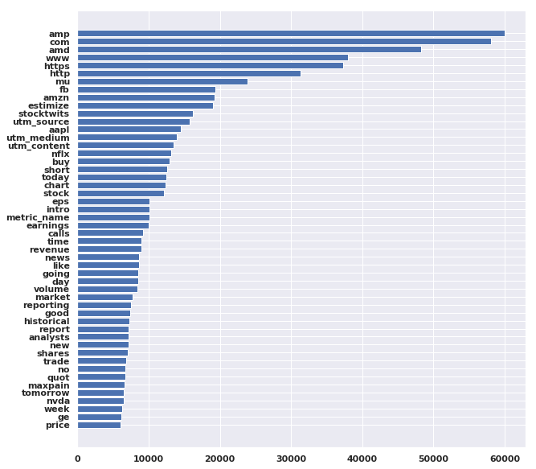

```python
font = {'family' : 'normal',
        'weight' : 'bold'}

plt.rc('font', **font)
fig = plt.figure(figsize=(10,10))
plt.barh(values[:50], counts[:50])
plt.gca().invert_yaxis()
plt.show()
```

#### Converting Train Data suitable for Vectorization:

```python
# tfidf vectorizer needs sentence and not token. Hence we need to combine all the tokens back to form a string

preprocess_Train['clean_text_stemmed'] = [' '.join(text) for text in preprocess_Train['clean_text_stemmed']]
preprocess_Train['clean_text_lemmatized'] = [' '.join(text) for text in preprocess_Train['clean_text_lemmatized']]
preprocess_Train['clean_text_lemmatized'][0]
```

```
'fitb great buy ill wait'
```

#### Converting Test Data suitable for Vectorization:

```python
#tfidf vectorizer needs sentence and not token. Hence we need to combine all the tokens back to form a string

preprocess_Test['clean_text_stemmed'] = [' '.join(text) for text in preprocess_Test['clean_text_stemmed']]
preprocess_Test['clean_text_lemmatized'] = [' '.join(text) for text in preprocess_Test['clean_text_lemmatized']]
preprocess_Test['clean_text_lemmatized'][0]
```

```
'staanalystalert tdg jefferie maintain rating hold set target price usd verdict buy http www stocktargetadvisor com toprate'
```

### Train Test split:

```python
from sklearn.model_selection import train_test_split
x_train, x_val, y_train, y_val = train_test_split(preprocess_Train['clean_text_lemmatized'],preprocess_Train['sentiment_score'],test_size=0.20,random_state=123)
```

#### TFIDF Vectorization

```python
from sklearn.feature_extraction.text import TfidfVectorizer
```

```python
#define tf-idf object
tfidf_vectorizer = TfidfVectorizer(max_df=0.9, max_features=20000,
                                 min_df=0.2,
                                 use_idf=True, ngram_range=(1,4))

#tfidf_vectorizer.fit(data['clean_text_lemmatized'])
tfidf_vectorizer.fit(x_train)
```

```
TfidfVectorizer(analyzer='word', binary=False, decode_error='strict',
                dtype=<class 'numpy.float64'>, encoding='utf-8',
                input='content', lowercase=True, max_df=0.9, max_features=20000,
                min_df=0.2, ngram_range=(1, 4), norm='l2', preprocessor=None,
                smooth_idf=True, stop_words=None, strip_accents=None,
                sublinear_tf=False, token_pattern='(?u)\\b\\w\\w+\\b',
                tokenizer=None, use_idf=True, vocabulary=None)
```

```python
# x_train_tfidf is tiidf form of xtrain which will be passed as an argument to the Models
x_train_tfidf = tfidf_vectorizer.transform(x_train)
```

```python
# x_val_tfidf is tiidf form of xval which will be passed as an argument to the Models
x_val_tfidf = tfidf_vectorizer.transform(x_val)
```

```python
# x_Test_tfidf = tfidf_vectorizer.transform(testData_Tweet)
```

#### Count Vectorizor:

```python
# Subsetting only tweets from the test data for vectorization.
testData_Tweet = preprocess_Test['clean_text_lemmatized']
```

```python
#Impoting countvectorizer library
from sklearn.feature_extraction.text import CountVectorizer
from sklearn.metrics import confusion_matrix, f1_score
from sklearn.feature_extraction.text import TfidfVectorizer

cv=CountVectorizer(stop_words='english',lowercase=True,strip_accents='unicode',decode_error='ignore')
```

```python
#Fit and transform the countvectorizer object on data
cv.fit(x_train)
```

```
CountVectorizer(analyzer='word', binary=False, decode_error='ignore',
                dtype=<class 'numpy.int64'>, encoding='utf-8', input='content',
                lowercase=True, max_df=1.0, max_features=None, min_df=1,
                ngram_range=(1, 1), preprocessor=None, stop_words='english',
                strip_accents='unicode', token_pattern='(?u)\\b\\w\\w+\\b',
                tokenizer=None, vocabulary=None)
```

```python
# Creating Train cv matrix
x_train_vec = cv.transform(x_train)
```

```python
# Creating validation cv matrix
x_val_vec = cv.transform(x_val)
```

```python
#CV for Actual unseen Test data:
x_Test_vec = cv.transform(testData_Tweet)
```

## Model Building

### Multinomial NaiveBayes:

```python
# Multinomial Naive Bayes
classifier_TFIDF = MultinomialNB()
```

```python
classifier_TFIDF.fit(x_train_vec,y_train)
```

```
MultinomialNB(alpha=1.0, class_prior=None, fit_prior=True)
```

```python
# Predictions on train data
y_pred_TFIDF_Train =classifier_TFIDF.predict(x_train_vec)
print("confusion_matrix on train data\n",confusion_matrix(y_train,y_pred_TFIDF_Train))
```

```
confusion_matrix on train data
 [[ 43754   2697   7230  12369   7437]
 [ 14854  27566  13126  29700  11494]
 [ 21179   7915 210068  98775  33740]
 [ 11473   7187  25909  90912  30890]
 [  2768   1043  12650  25214  81354]]
```

```python
# classification report for Train data:
print(classification_report(y_true=y_train,y_pred=y_pred_TFIDF_Train))
```

```
              precision    recall  f1-score   support

           0       0.47      0.60      0.52     73487
           1       0.59      0.28      0.39     96740
           2       0.78      0.57      0.66    371677
           3       0.35      0.55      0.43    166371
           4       0.49      0.66      0.57    123029

    accuracy                           0.55    831304
   macro avg       0.54      0.53      0.51    831304
weighted avg       0.60      0.55      0.55    831304
```

```python
# F1 Score for Train data:
print(f1_score(y_train, y_pred_TFIDF_Train, average="macro"))
```

```
0.5115762113430004
```

```python
# Predictions on train data
y_pred_TFIDF_val =classifier_TFIDF.predict(x_val_vec)
print("confusion_matrix on train data\n",confusion_matrix(y_val,y_pred_TFIDF_val))
```

```
confusion_matrix on train data
 [[10446   746  1917  3473  1953]
 [ 3828  6077  3608  7674  2844]
 [ 4830  2106 51744 25591  8454]
 [ 2990  1870  7313 21047  8440]
 [  740   299  3410  7181 19246]]
```

```python
# classification report for validation data:
print(classification_report(y_true=y_val,y_pred=y_pred_TFIDF_val))
```

```
              precision    recall  f1-score   support

           0       0.46      0.56      0.51     18535
           1       0.55      0.25      0.35     24031
           2       0.76      0.56      0.64     92725
           3       0.32      0.51      0.39     41660
           4       0.47      0.62      0.54     30876

    accuracy                           0.52    207827
   macro avg       0.51      0.50      0.49    207827
weighted avg       0.58      0.52      0.53    207827
```

```python
# F1 Score for Validation data:
print(f1_score(y_val, y_pred_TFIDF_val, average="macro"))
```

```
0.48513944696751815
```

### Random Forest:

```python
from sklearn.ensemble import RandomForestClassifier

# Create the model with 100 trees
Classifier_RF = RandomForestClassifier(criterion='entropy',n_estimators=50,max_depth=500,bootstrap = True,max_features = 'sqrt'
                                       ,min_samples_leaf=2,random_state=123)
```

```python
# Fit on training data
Classifier_RF.fit(x_train_vec, y_train)
```

```
RandomForestClassifier(bootstrap=True, class_weight=None, criterion='entropy',
                       max_depth=500, max_features='sqrt', max_leaf_nodes=None,
                       min_impurity_decrease=0.0, min_impurity_split=None,
                       min_samples_leaf=2, min_samples_split=2,
                       min_weight_fraction_leaf=0.0, n_estimators=50,
                       n_jobs=None, oob_score=False, random_state=123,
                       verbose=0, warm_start=False)
```

```python
# Predictions on train data
y_Train_Pred_RF =Classifier_RF.predict(x_train_vec)
print("confusion_matrix on train data\n",confusion_matrix(y_train,y_Train_Pred_RF))
```

```
confusion_matrix on train data
 [[ 31407   3142  32496   3394   3048]
 [  3087  27582  49818  10476   5777]
 [  3689   1428 346974  11294   8292]
 [  3256   4569  88218  58470  11858]
 [   531    386  37236  17802  67074]]
```

```python
# classification report for Train data:
print(classification_report(y_true=y_train,y_pred=y_Train_Pred_RF))
```

```
              precision    recall  f1-score   support

           0       0.75      0.43      0.54     73487
           1       0.74      0.29      0.41     96740
           2       0.63      0.93      0.75    371677
           3       0.58      0.35      0.44    166371
           4       0.70      0.55      0.61    123029

    accuracy                           0.64    831304
   macro avg       0.68      0.51      0.55    831304
weighted avg       0.65      0.64      0.61    831304
```

```python
# F1 Score for Train data:
print(f1_score(y_train, y_Train_Pred_RF, average="macro"))
```

```
0.5508482937684251
```

```python
# Predictions on Validation data
y_Test_Pred_RF =Classifier_RF.predict(x_val_vec)
print("confusion_matrix on train data\n",confusion_matrix(y_val,y_Test_Pred_RF))
```

```
confusion_matrix on train data
 [[ 7524   814  8595   871   731]
 [  781  6488 12657  2644  1461]
 [ 1008   429 85772  3235  2281]
 [  855  1153 22718 13672  3262]
 [  135   111  9979  4970 15681]]
```

```python
# classification report for Validation data:
print(classification_report(y_true=y_val,y_pred=y_Test_Pred_RF))

# F1 Score for Validation data:
print(f1_score(y_val, y_Test_Pred_RF, average="macro"))
```

```
              precision    recall  f1-score   support

           0       0.73      0.41      0.52     18535
           1       0.72      0.27      0.39     24031
           2       0.61      0.93      0.74     92725
           3       0.54      0.33      0.41     41660
           4       0.67      0.51      0.58     30876

    accuracy                           0.62    207827
   macro avg       0.65      0.49      0.53    207827
weighted avg       0.63      0.62      0.59    207827

0.5276332374311345
```

### XGBoost:

```python
from xgboost import XGBClassifier
```

```python
# fit model no training data
# gbtree, gblinear or dart.
XG_Classifier = XGBClassifier(max_depth=7,n_estimators=100,learning_rate=0.1,booster='dart')
```

```python
XG_Classifier.fit(x_train_vec, y_train)
```

```
XGBClassifier(base_score=0.5, booster='dart', colsample_bylevel=1,
              colsample_bynode=1, colsample_bytree=1, gamma=0,
              learning_rate=0.1, max_delta_step=0, max_depth=7,
              min_child_weight=1, missing=None, n_estimators=100, n_jobs=1,
              nthread=None, objective='multi:softprob', random_state=0,
              reg_alpha=0, reg_lambda=1, scale_pos_weight=1, seed=None,
              silent=None, subsample=1, verbosity=1)
```

```python
# Predictions on train data
XGTrain_Pred = XG_Classifier.predict(x_train_vec)
```

```python
#classification report for Train data:
print(classification_report(y_true=y_train,y_pred=XGTrain_Pred))
```

```
              precision    recall  f1-score   support

           0       0.66      0.47      0.55     73487
           1       0.62      0.33      0.43     96740
           2       0.62      0.92      0.74    371677
           3       0.59      0.31      0.41    166371
           4       0.70      0.51      0.59    123029

    accuracy                           0.63    831304
   macro avg       0.64      0.51      0.54    831304
weighted avg       0.63      0.63      0.60    831304
```

```python
# F1 Score for Train data:
print(f1_score(y_train, XGTrain_Pred, average="macro"))
```

```
0.5446423615339734
```

```python
# Predictions on Validation data
XGTest_Pred = XG_Classifier.predict(x_val_vec)
```

```python
#classification report for Validation data:
print(classification_report(y_true=y_val,y_pred=XGTest_Pred))
```

```
              precision    recall  f1-score   support

           0       0.66      0.47      0.55     18535
           1       0.62      0.33      0.43     24031
           2       0.62      0.92      0.74     92725
           3       0.58      0.31      0.40     41660
           4       0.69      0.50      0.58     30876

    accuracy                           0.63    207827
   macro avg       0.63      0.50      0.54    207827
weighted avg       0.63      0.63      0.60    207827
```

```python
# F1 Score for Validation data:
print(f1_score(y_val, XGTest_Pred, average="macro"))
```

```
0.5395252731471903
```

```python
# Prediction for unseen data.
actualTestScore = XG_Classifier.predict(x_Test_vec)
```

#### XGB gave a better F1 score of 0.53 when compared with other Modelsand hence it its been used to predict the sentiment score of the Test tweets.

### Creating Test score Dataframe:

```python
ScoreSubmission_df = pd.DataFrame(columns=['timestamp','ticker','sentiment_score'])
```

```python
ScoreSubmission_df['sentiment_score'] = actualTestScore
```

```python
ScoreSubmission_df['ticker'] = preprocess_Test['ticker']
```

```python
ScoreSubmission_df['timestamp'] = preprocess_Test['timestamp']
```

```python
ScoreSubmission_df.head()
```

|  | timestamp | ticker | sentiment_score |
| --- | --- | --- | --- |
| 0 | 2018-07-01 00:01:24 | $TDG | 4 |
| 1 | 2018-07-01 00:09:36 | $SNPS | 0 |
| 2 | 2018-07-01 00:12:58 | $NFLX | 3 |
| 3 | 2018-07-01 00:30:01 | $URI | 0 |
| 4 | 2018-07-01 00:32:03 | $K | 2 |

```python
ScoreSubmission_df.isnull().sum()
```

```
timestamp          0
ticker             0
sentiment_score    0
dtype: int64
```

```python
ScoreSubmission_df.shape
```

```
(265022, 3)
```

```python
ScoreSubmission_df.to_csv('ScoreSubmission_df.csv')
```

### Converting preprocess train and test into a dataframe for future use:

```python
preprocess_Train_csv = pd.DataFrame(preprocess_Train)
preprocess_Test_csv  = pd.DataFrame(preprocess_Test)
```

```python
preprocess_Train_csv.to_csv("preprocess_Train_csv.csv")
preprocess_Test_csv.to_csv("preprocess_Test_csv.csv")
```

## Analysing CSV data for Alpha Signals

### Reading Test,Train and wiki CSV files

```python
#Reading the CSV which consist of the 7 influential factors for the Alpha value..
trainFactors_df = pd.read_csv('train_factors-1573207730757.csv',parse_dates=[0])
testFactors_df  = pd.read_csv('test_factors.csv',parse_dates=[0])
wikiTickers_df  = pd.read_csv('secwiki_tickers.csv')
```

### Reading the json data for integration with CSV:

```python
#Getting the Train json csv file into a dataframe
Sentiment_Train_df=pd.read_json('train_data-1573118738755.json',orient='columns')
Sentiment_Train_df=pd.read_json( (Sentiment_Train_df['records']).to_json(),orient='index')
Sentiment_Test_df = pd.read_csv('ScoreSubmission_df.csv',parse_dates=[0])
```

```python
trainFactors_df.head()
```

|  | Id | date | ticker | SF1 | SF2 | SF3 | SF4 | SF5 | SF6 | SF7 | alpha |
| --- | --- | --- | --- | --- | --- | --- | --- | --- | --- | --- | --- |
| 0 | 1 | 21/08/18 | $NTAP | -0.628652 | 0.988891 | -0.055714 | 0.774379 | 0.551089 | -1.329229 | -0.995539 | 2 |
| 1 | 2 | 11/10/18 | $WYNN | 1.315786 | 1.438754 | 0.187327 | 0.608933 | -1.153030 | 1.859441 | 0.730995 | 3 |
| 2 | 3 | 21/08/18 | $DRI | -1.141388 | -1.455016 | 0.332755 | 0.674502 | 0.111326 | -0.478597 | -1.488157 | 1 |
| 3 | 4 | 10/07/18 | $ge | -0.054839 | -1.454149 | -0.162267 | -0.681870 | 0.307869 | -0.529987 | 0.404172 | 2 |
| 4 | 5 | 12/09/18 | $FE | -0.686366 | 0.838865 | 0.073830 | 0.679024 | 0.329463 | 1.262782 | -1.024042 | 2 |

```python
testFactors_df.head()
```

|  | Id | date | ticker | SF1 | SF2 | SF3 | SF4 | SF5 | SF6 | SF7 |
| --- | --- | --- | --- | --- | --- | --- | --- | --- | --- | --- |
| 0 | 270007 | 21/07/18 | $INTC | -3.062194 | 1.223466 | 1.741714 | 2.279266 | -1.323573 | -0.274912 | -4.504449 |
| 1 | 270008 | 05/10/18 | $CTSH | 0.816263 | -2.184408 | 0.157975 | -0.264743 | -0.836282 | 0.046276 | 0.826353 |
| 2 | 270009 | 01/10/18 | $CB | 0.401281 | 0.091604 | 0.083411 | -1.147041 | -0.485223 | -0.601060 | 1.012811 |
| 3 | 270010 | 24/10/18 | $CTAS | -0.783521 | 1.192929 | 0.813831 | -0.368166 | -1.113656 | -0.553581 | -0.683803 |
| 4 | 270011 | 27/07/18 | $intc | 0.796507 | 0.455341 | 0.679032 | 0.354336 | -1.799055 | 0.126153 | 0.297111 |

```python
wikiTickers_df.head()
```

|  | Ticker | Name | Sector | Industry | Price | Collection |
| --- | --- | --- | --- | --- | --- | --- |
| 0 | A | Agilent Technologies Inc. | Healthcare | Medical Laboratories & Research | WIKI/A | stocks/a |
| 1 | AA | Alcoa Inc. | Basic Materials | Aluminum | WIKI/AA | stocks/aa |
| 2 | AAME | Atlantic American Corp. | Financial | Life Insurance | NaN | stocks/aame |
| 3 | AAN | Aaron's, Inc. | Services | Rental & Leasing Services | WIKI/AAN | stocks/aan |
| 4 | AAON | AAON Inc. | Industrial Goods | General Building Materials | WIKI/AAON | stocks/aaon |

```python
print("Shape Train Factors is = ",trainFactors_df.shape)
print("Shape Test Factors  is = ",testFactors_df.shape)
print("Shape Wiki Tickers  is = ",wikiTickers_df.shape)
```

```
Shape Train Factors is =  (27006, 11)
Shape Test Factors  is =  (11575, 10)
Shape Wiki Tickers  is =  (3339, 6)
```

```python
trainFactors_df.describe()
```

|  | SF1 | SF2 | SF3 | SF4 | SF5 | SF6 | SF7 | alpha |
| --- | --- | --- | --- | --- | --- | --- | --- | --- |
| count | 27006.000000 | 27006.000000 | 27006.000000 | 27006.000000 | 27006.000000 | 27006.000000 | 27006.000000 | 27006.000000 |
| mean | 0.005429 | -0.001005 | -0.024421 | -0.042420 | 0.041465 | 0.002597 | 0.036744 | 2.379582 |
| std | 0.941853 | 0.996130 | 0.539555 | 1.111309 | 0.976028 | 0.998839 | 1.204473 | 1.008681 |
| min | -4.114670 | -4.578587 | -2.609150 | -6.329798 | -5.480268 | -4.338751 | -5.347869 | 1.000000 |
| 25% | -0.596792 | -0.666310 | -0.300187 | -0.767247 | -0.518641 | -0.668027 | -0.688198 | 2.000000 |
| 50% | 0.012104 | -0.013257 | -0.040786 | -0.058629 | 0.072127 | 0.007417 | 0.081374 | 2.000000 |
| 75% | 0.611574 | 0.669094 | 0.241424 | 0.677433 | 0.616538 | 0.674592 | 0.807556 | 3.000000 |
| max | 4.415048 | 3.822270 | 3.452486 | 4.907407 | 4.779911 | 4.075428 | 5.182912 | 4.000000 |

```python
## desctiption
```

#### Checking Train data types:

```python
# Checking the data types for all the factors.
trainFactors_df.dtypes
```

```
Id         object
date       object
ticker     object
SF1       float64
SF2       float64
SF3       float64
SF4       float64
SF5       float64
SF6       float64
SF7       float64
alpha       int64
dtype: object
```

#### Type conversion:

```python
# The date and ticker has to be converted to it respective data types.
trainFactors_df['ticker'] = trainFactors_df['ticker'].astype('category')
trainFactors_df['date'] = pd.to_datetime(trainFactors_df['date'], dayfirst = True)
```

### Alpha Value = Actual rate of return – Expected rate of return

#### Alpha value is the excess return obtained from a fund

```
Total number of data which has Alpha value 2 =  10912
```

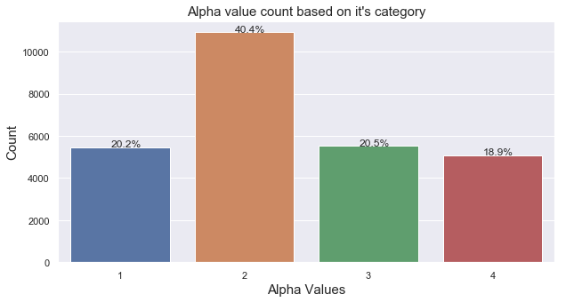

```python
print("Total number of data which has Alpha value 2 = ",len(trainFactors_df[trainFactors_df.alpha==2]))
#Total number of data in the CSV file.
total = 27006
sns.set(rc={'figure.figsize':(10,5)})
plot = sns.countplot(x="alpha",data=trainFactors_df)
plt.title("Alpha value count based on it's category",fontsize=15)
plt.xlabel("Alpha Values",fontsize=15)
plt.ylabel("Count",fontsize=15)
for p in plot.patches:
    plot.annotate('{:.1f}%'.format(100*p.get_height()/total), (p.get_x()+0.325, p.get_height()+5))
```

#### More than 40% data has a Alpha score of 2 and remaining scores are in the same range.

### Insight for a Single Entity(Ticker) - NetApp Inc, Amazon and Facebook.

```python
def GetEntityGraph(ticker):
    stockName = GetTickerName(ticker)
    print(stockName, ticker)
    App_df = trainFactors_df[trainFactors_df.ticker == ticker]
#     print(display(App_df))
    App_df_date = App_df[['date','alpha']]
    App_df_date = App_df_date.reset_index(drop=True)
    App_df_date = App_df_date.sort_values(by=['date'])
    App_df_date['week']=App_df_date['date'].dt.week
    print(display(App_df_date.head()))
    App_df_week = pd.DataFrame(pd.Series(App_df_date.groupby('week')['alpha'].mean()))
    App_df_week.plot()
    return App_df_date,App_df_week

# getting the Entity name for ticker which is been provided in csv. The name is fetched from the Wiki CSV file which is found in open source
def GetTickerName(ticker):
    nticker = re.sub(r'[^\w]','', ticker)
    nticker = nticker.upper()
    name = ""
    name = wikiTickers_df.loc[wikiTickers_df["Ticker"]==nticker,'Name']
    name = name.to_string()
    name = re.sub(r'[\d]','', name)
    return name
```

#### Plotting the Alpha graph for NETAPP:

```
    NetApp, Inc. $NTAP
```

|  | date | alpha | week |
| --- | --- | --- | --- |
| 49 | 2018-07-01 | 4 | 26 |
| 36 | 2018-07-03 | 1 | 27 |
| 21 | 2018-07-05 | 2 | 27 |
| 27 | 2018-07-07 | 4 | 27 |
| 26 | 2018-07-09 | 3 | 28 |

```
None
```

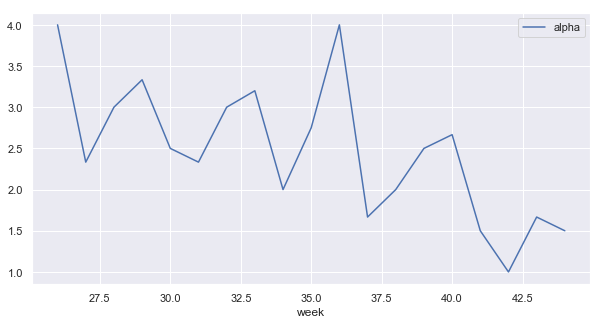

```python
#Getting the entity graph for NetApp.
netApp_date,netApp_week = GetEntityGraph('$NTAP')
```

```python
netApp_date[netApp_date.week==27]
```

|  | date | alpha | week |
| --- | --- | --- | --- |
| 36 | 2018-07-03 | 1 | 27 |
| 21 | 2018-07-05 | 2 | 27 |
| 27 | 2018-07-07 | 4 | 27 |

```python
 Image(url= "https://zdnet4.cbsistatic.com/hub/i/r/2018/02/14/be75cda4-6079-4c70-af16-51da7986aa7c/resize/770xauto/39c77c1c6046c2983844aaf53c6f518d/netapp-q3-earnings.png")
```

[figure not shown]

### Plotting the Alpha graph for AMAZON:

```
    Amazon.com Inc. $amzn
```

|  | date | alpha | week |
| --- | --- | --- | --- |
| 44 | 2018-07-02 | 2 | 27 |
| 17 | 2018-07-06 | 2 | 27 |
| 4 | 2018-07-10 | 4 | 28 |
| 9 | 2018-07-11 | 2 | 28 |
| 2 | 2018-07-13 | 4 | 28 |

```
None
```

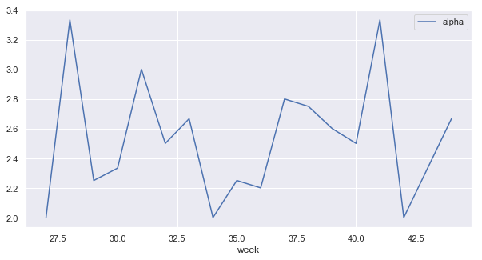

```python
# Getting the entity graph for Amazon.
amazon_date,amazon_week = GetEntityGraph('$amzn')
```

```python
amazon_date.head()
```

|  | date | alpha | week |
| --- | --- | --- | --- |
| 44 | 2018-07-02 | 2 | 27 |
| 17 | 2018-07-06 | 2 | 27 |
| 4 | 2018-07-10 | 4 | 28 |
| 9 | 2018-07-11 | 2 | 28 |
| 2 | 2018-07-13 | 4 | 28 |

#### Amazon has seasonal variations in its Alpha value. The alpha value was in a good shape when the Q2 results where announced and held its position between 2-3 after which there was a light decline in the salse which made the alpha value go down.

#### In the beginning of the Q4 the alpha value started to rise again due increase in salse(festival season).

### reference https://ir.aboutamazon.com/quarterly-results

### Plotting the Alpha graph for Facebook:

```
    Facebook, Inc. $fb
```

|  | date | alpha | week |
| --- | --- | --- | --- |
| 51 | 2018-07-01 | 4 | 26 |
| 45 | 2018-07-05 | 1 | 27 |
| 37 | 2018-07-10 | 2 | 28 |
| 3 | 2018-07-12 | 4 | 28 |
| 8 | 2018-07-13 | 2 | 28 |

```
None
```

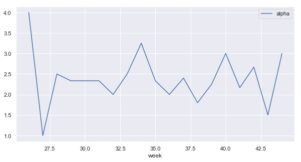

```python
# Getting the entity graph for Facebook.
fb_date,fb_week = GetEntityGraph('$fb')
```

#### The users enguagement factor was huge at the start and end of the year but remained normal during the other seasons.

#### Q3 results in Sep end, The number of daily users on the platform also appeared to bounce back, indicating steady engagement despite backlash surrounding the leak of personal information to firms such as Cambridge Analytica. Shares jumped about 6 percent after the results were released.

#### Earnings per share: 1.69 adjusted vs. 1.35 expected by a Thomson Reuters consensus estimate

### Influence of the seven factors over the alpha value

|  | SF1 | SF2 | SF3 | SF4 | SF5 | SF6 | SF7 | alpha |
| --- | --- | --- | --- | --- | --- | --- | --- | --- |
| SF1 | 1.000000 | 0.003338 | -0.385151 | -0.156248 | -0.202912 | 0.003960 | 0.814309 | 0.002482 |
| SF2 | 0.003338 | 1.000000 | -0.007591 | -0.015122 | 0.005073 | -0.016984 | 0.011543 | 0.000762 |
| SF3 | -0.385151 | -0.007591 | 1.000000 | 0.262503 | -0.823332 | -0.013038 | -0.529095 | -0.044415 |
| SF4 | -0.156248 | -0.015122 | 0.262503 | 1.000000 | -0.117114 | -0.006745 | -0.690205 | 0.153574 |
| SF5 | -0.202912 | 0.005073 | -0.823332 | -0.117114 | 1.000000 | 0.011143 | 0.026781 | 0.057072 |
| SF6 | 0.003960 | -0.016984 | -0.013038 | -0.006745 | 0.011143 | 1.000000 | 0.008009 | 0.008481 |
| SF7 | 0.814309 | 0.011543 | -0.529095 | -0.690205 | 0.026781 | 0.008009 | 1.000000 | -0.077634 |
| alpha | 0.002482 | 0.000762 | -0.044415 | 0.153574 | 0.057072 | 0.008481 | -0.077634 | 1.000000 |

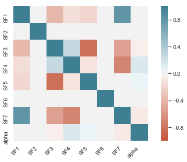

```python
#  Correlation plot to determine the togetherness of the features
corr = trainFactors_df.corr()
ax = sns.heatmap(
    corr,
    vmin=-1, vmax=1, center=0,
    cmap=sns.diverging_palette(20, 220, n=200),
    square=True
)
ax.set_xticklabels(
    ax.get_xticklabels(),
    rotation=45,
    horizontalalignment='right'
);
corr
```

#### Factor SF7 is highly correlated with SF1. Apart from this there are quite a few correlation between other factors like SF4 and SF3 which is 0.26.

#### Each of these 7 factors(Individual) have minor influence Alpha value.

#### Getting the Sentiment score for merging it with the csv data: Analysis

```python
def GetCorrelationPlot(dataframe):
    # Correlation plot to determine the togetherness of the features
    corr = dataframe.corr()
    ax = sns.heatmap(
        corr,
        vmin=-1, vmax=1, center=0,
        cmap=sns.diverging_palette(20, 220, n=200),
        square=True
    )
    ax.set_xticklabels(
        ax.get_xticklabels(),
        rotation=45,
        horizontalalignment='right'
    );
    print(corr)
```

```python
ori_json = pd.read_json('train_data-1573118738755.json',orient='columns')
ori_json = pd.read_json( (ori_json['records']).to_json(),orient='index')
```

```python
trainDataTemp_df = copy.deepcopy(ori_json)
```

```python
trainDataTemp_df = trainDataTemp_df[['timestamp','ticker','sentiment_score']]
```

```python
stdCpy = copy.deepcopy(trainDataTemp_df)
```

```python
trainDataTemp_df.dtypes
```

```
timestamp          datetime64[ns]
ticker                     object
sentiment_score             int64
dtype: object
```

```python
trainDataTemp_df['ticker'] = trainDataTemp_df['ticker'].astype('category')
```

```python
trainDataTemp_df=trainDataTemp_df.rename(columns = {'timestamp':'date'})
```

```python
trainDataTemp_df = trainDataTemp_df[['ticker','sentiment_score']]
```

```python
# group the sentiment score based only on ticker.
trainDataTemp_df = trainDataTemp_df.groupby('ticker')['sentiment_score'].mean()
```

```python
trainDataTemp_df = trainDataTemp_df.reset_index()
```

```python
# Merging the sentiment score data with the alpha value dataframe
trainFactors_merge_df = pd.merge(trainFactors_df, trainDataTemp_df, on='ticker')
```

```
                      SF1       SF2       SF3       SF4       SF5       SF6  \
SF1              1.000000  0.002884 -0.385531 -0.156308 -0.202890  0.003560
SF2              0.002884  1.000000 -0.008468 -0.014709  0.006321 -0.016004
SF3             -0.385531 -0.008468  1.000000  0.262840 -0.823110 -0.012521
SF4             -0.156308 -0.014709  0.262840  1.000000 -0.117383 -0.005947
SF5             -0.202890  0.006321 -0.823110 -0.117383  1.000000  0.010888
SF6              0.003560 -0.016004 -0.012521 -0.005947  0.010888  1.000000
SF7              0.814365  0.011111 -0.529460 -0.690194  0.026852  0.007231
alpha            0.002205  0.001604 -0.043805  0.154674  0.056676  0.007986
sentiment_score -0.001618 -0.000337  0.018130  0.045571 -0.015305  0.004952

                      SF7     alpha  sentiment_score
SF1              0.814365  0.002205        -0.001618
SF2              0.011111  0.001604        -0.000337
SF3             -0.529460 -0.043805         0.018130
SF4             -0.690194  0.154674         0.045571
SF5              0.026852  0.056676        -0.015305
SF6              0.007231  0.007986         0.004952
SF7              1.000000 -0.078494        -0.028452
alpha           -0.078494  1.000000         0.148804
sentiment_score -0.028452  0.148804         1.000000
```

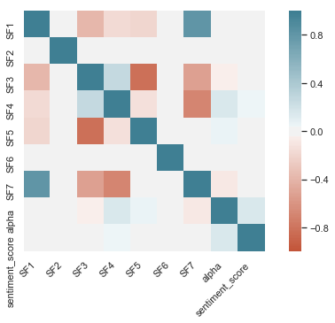

```python
GetCorrelationPlot(trainFactors_merge_df)
```

#### The sentiment score have around 14% influence on the alpha value but it seem it has no correlation with other 7 factors.

### Merge sentiment score on basis for each ticker and Month.

```python
import copy
trainDataTemp_df=pd.read_json('train_data-1573118738755.json',orient='columns')
trainDataTemp_df=pd.read_json( (trainDataTemp_df['records']).to_json(),orient='index')
original_jsondata = copy.deepcopy(trainDataTemp_df)
```

```python
sentiment_monthly_df = copy.deepcopy(original_jsondata)
```

```python
sentiment_monthly_df['Month'] = sentiment_monthly_df['timestamp'].dt.month_name(locale = 'English')
```

```python
sentiment_monthly_df.drop('timestamp',axis = 1, inplace= True)
```

```python
sentiment_monthly_df = pd.DataFrame(sentiment_monthly_df.groupby(['ticker','Month'])['sentiment_score'].mean())
```

```python
sentiment_monthly_df = sentiment_monthly_df.reset_index()
```

```python
sentiment_monthly_df.head()
```

|  | ticker | Month | sentiment_score |
| --- | --- | --- | --- |
| 0 | $$AAPL | August | 1.666667 |
| 1 | $$ATVI | July | 1.000000 |
| 2 | $$BIIB | July | 2.000000 |
| 3 | $$C | September | 3.000000 |
| 4 | $$DNR | August | 4.000000 |

```python
trainMonth = copy.deepcopy(trainFactors_df)
```

```python
trainMonth.head()
```

|  | Id | date | ticker | SF1 | SF2 | SF3 | SF4 | SF5 | SF6 | SF7 | alpha |
| --- | --- | --- | --- | --- | --- | --- | --- | --- | --- | --- | --- |
| 0 | 1 | 2018-08-21 | $NTAP | -0.628652 | 0.988891 | -0.055714 | 0.774379 | 0.551089 | -1.329229 | -0.995539 | 2 |
| 1 | 2 | 2018-10-11 | $WYNN | 1.315786 | 1.438754 | 0.187327 | 0.608933 | -1.153030 | 1.859441 | 0.730995 | 3 |
| 2 | 3 | 2018-08-21 | $DRI | -1.141388 | -1.455016 | 0.332755 | 0.674502 | 0.111326 | -0.478597 | -1.488157 | 1 |
| 3 | 4 | 2018-07-10 | $ge | -0.054839 | -1.454149 | -0.162267 | -0.681870 | 0.307869 | -0.529987 | 0.404172 | 2 |
| 4 | 5 | 2018-09-12 | $FE | -0.686366 | 0.838865 | 0.073830 | 0.679024 | 0.329463 | 1.262782 | -1.024042 | 2 |

```python
trainMonth['Month'] = trainMonth['date'].dt.month_name(locale = 'English')
```

```python
trainFactors_Month_df = pd.merge(trainMonth, sentiment_monthly_df, on=['ticker','Month'])
```

```python
trainFactors_Month_df.head()
```

|  | Id | date | ticker | SF1 | SF2 | SF3 | SF4 | SF5 | SF6 | SF7 | alpha | Month | sentiment_score |
| --- | --- | --- | --- | --- | --- | --- | --- | --- | --- | --- | --- | --- | --- |
| 0 | 1 | 2018-08-21 | $NTAP | -0.628652 | 0.988891 | -0.055714 | 0.774379 | 0.551089 | -1.329229 | -0.995539 | 2 | August | 2.257225 |
| 1 | 525 | 2018-08-07 | $NTAP | -1.029133 | 0.060270 | 0.462320 | 0.764254 | -0.205632 | 0.693210 | -1.479310 | 4 | August | 2.257225 |
| 2 | 2730 | 2018-08-24 | $NTAP | -0.842490 | -0.124624 | -0.033443 | 1.267211 | 0.672557 | -1.104586 | -1.482598 | 2 | August | 2.257225 |
| 3 | 7141 | 2018-08-30 | $NTAP | 1.272172 | -0.221317 | 0.270765 | 1.490408 | -1.233391 | -0.580988 | 0.143146 | 4 | August | 2.257225 |
| 4 | 8032 | 2018-08-10 | $NTAP | -0.217988 | -0.388794 | -1.051849 | -1.751976 | 2.074406 | -0.592174 | 1.144112 | 2 | August | 2.257225 |

```
                      SF1       SF2       SF3       SF4       SF5       SF6  \
SF1              1.000000  0.002675 -0.385902 -0.155158 -0.202297  0.003947
SF2              0.002675  1.000000 -0.008569 -0.014868  0.006548 -0.015739
SF3             -0.385902 -0.008569  1.000000  0.262562 -0.823227 -0.013211
SF4             -0.155158 -0.014868  0.262562  1.000000 -0.117896 -0.006434
SF5             -0.202297  0.006548 -0.823227 -0.117896  1.000000  0.011365
SF6              0.003947 -0.015739 -0.013211 -0.006434  0.011365  1.000000
SF7              0.814225  0.011071 -0.529833 -0.689523  0.027565  0.007851
alpha            0.002332  0.001923 -0.043864  0.154286  0.056644  0.007627
sentiment_score -0.003855  0.001710  0.011910  0.045592 -0.007263  0.006503

                      SF7     alpha  sentiment_score
SF1              0.814225  0.002332        -0.003855
SF2              0.011071  0.001923         0.001710
SF3             -0.529833 -0.043864         0.011910
SF4             -0.689523  0.154286         0.045592
SF5              0.027565  0.056644        -0.007263
SF6              0.007851  0.007627         0.006503
SF7              1.000000 -0.078190        -0.029235
alpha           -0.078190  1.000000         0.166895
sentiment_score -0.029235  0.166895         1.000000
```

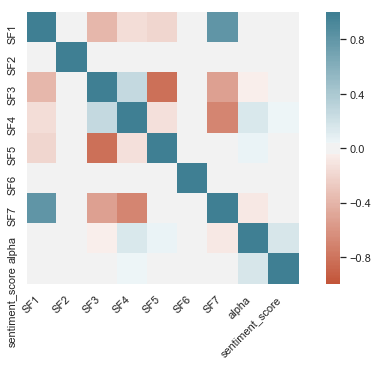

```python
GetCorrelationPlot(trainFactors_Month_df)
```

### Merge sentiment score on basis for each ticker and week.

```python
stdCpy.head()
```

|  | timestamp | ticker | sentiment_score |
| --- | --- | --- | --- |
| 0 | 2018-09-19 18:38:28 | $AMD | 3 |
| 1 | 2018-10-09 03:51:06 | $CAT | 3 |
| 2 | 2018-07-12 13:35:32 | $AVGO | 2 |
| 3 | 2018-07-19 03:32:50 | $PH | 2 |
| 4 | 2018-08-23 19:07:54 | $FB | 3 |

```python
sentiment_weekly_df = copy.deepcopy(stdCpy)
```

```python
sentiment_weekly_df['Week'] = sentiment_weekly_df['timestamp'].dt.week
```

```python
sentiment_weekly_df.head()
```

|  | timestamp | ticker | sentiment_score | Week |
| --- | --- | --- | --- | --- |
| 0 | 2018-09-19 18:38:28 | $AMD | 3 | 38 |
| 1 | 2018-10-09 03:51:06 | $CAT | 3 | 41 |
| 2 | 2018-07-12 13:35:32 | $AVGO | 2 | 28 |
| 3 | 2018-07-19 03:32:50 | $PH | 2 | 29 |
| 4 | 2018-08-23 19:07:54 | $FB | 3 | 34 |

```python
sentiment_weekly_df.drop('timestamp',axis = 1, inplace= True)
```

```python
sentiment_weekly_df = pd.DataFrame(sentiment_weekly_df.groupby(['ticker','Week'])['sentiment_score'].mean())
```

```python
sentiment_weekly_df = sentiment_weekly_df.reset_index()
```

```python
sentiment_weekly_df.head()
```

|  | ticker | Week | sentiment_score |
| --- | --- | --- | --- |
| 0 | $$AAPL | 31 | 1.75 |
| 1 | $$AAPL | 32 | 1.50 |
| 2 | $$ATVI | 29 | 1.00 |
| 3 | $$BIIB | 30 | 2.00 |
| 4 | $$C | 38 | 3.00 |

```python
trainWeek = copy.deepcopy(trainFactors_df)
```

```python
trainWeek['Week'] = trainWeek['date'].dt.week
```

```python
trainWeek.head()
```

|  | Id | date | ticker | SF1 | SF2 | SF3 | SF4 | SF5 | SF6 | SF7 | alpha | Week |
| --- | --- | --- | --- | --- | --- | --- | --- | --- | --- | --- | --- | --- |
| 0 | 1 | 2018-08-21 | $NTAP | -0.628652 | 0.988891 | -0.055714 | 0.774379 | 0.551089 | -1.329229 | -0.995539 | 2 | 34 |
| 1 | 2 | 2018-10-11 | $WYNN | 1.315786 | 1.438754 | 0.187327 | 0.608933 | -1.153030 | 1.859441 | 0.730995 | 3 | 41 |
| 2 | 3 | 2018-08-21 | $DRI | -1.141388 | -1.455016 | 0.332755 | 0.674502 | 0.111326 | -0.478597 | -1.488157 | 1 | 34 |
| 3 | 4 | 2018-07-10 | $ge | -0.054839 | -1.454149 | -0.162267 | -0.681870 | 0.307869 | -0.529987 | 0.404172 | 2 | 28 |
| 4 | 5 | 2018-09-12 | $FE | -0.686366 | 0.838865 | 0.073830 | 0.679024 | 0.329463 | 1.262782 | -1.024042 | 2 | 37 |

```python
trainFactors_Week_df = pd.merge(trainWeek, sentiment_weekly_df, on=['ticker','Week'])
```

```python
trainFactors_Week_df.head()
```

|  | Id | date | ticker | SF1 | SF2 | SF3 | SF4 | SF5 | SF6 | SF7 | alpha | Week | sentiment_score |
| --- | --- | --- | --- | --- | --- | --- | --- | --- | --- | --- | --- | --- | --- |
| 0 | 1 | 2018-08-21 | $NTAP | -0.628652 | 0.988891 | -0.055714 | 0.774379 | 0.551089 | -1.329229 | -0.995539 | 2 | 34 | 2.068966 |
| 1 | 2730 | 2018-08-24 | $NTAP | -0.842490 | -0.124624 | -0.033443 | 1.267211 | 0.672557 | -1.104586 | -1.482598 | 2 | 34 | 2.068966 |
| 2 | 2 | 2018-10-11 | $WYNN | 1.315786 | 1.438754 | 0.187327 | 0.608933 | -1.153030 | 1.859441 | 0.730995 | 3 | 41 | 2.081633 |
| 3 | 6114 | 2018-10-10 | $WYNN | 0.178090 | -1.330370 | -0.503886 | -0.829500 | 0.816917 | 0.426512 | 0.788326 | 2 | 41 | 2.081633 |
| 4 | 17853 | 2018-10-08 | $WYNN | 0.720759 | -0.384788 | -0.050033 | -2.408599 | -0.504363 | -0.402402 | 2.081868 | 2 | 41 | 2.081633 |

```
                      SF1       SF2       SF3       SF4       SF5       SF6  \
SF1              1.000000  0.003833 -0.386272 -0.153843 -0.202469  0.003848
SF2              0.003833  1.000000 -0.009141 -0.014324  0.006498 -0.015693
SF3             -0.386272 -0.009141  1.000000  0.262289 -0.822895 -0.013714
SF4             -0.153843 -0.014324  0.262289  1.000000 -0.118253 -0.007322
SF5             -0.202469  0.006498 -0.822895 -0.118253  1.000000  0.011902
SF6              0.003848 -0.015693 -0.013714 -0.007322  0.011902  1.000000
SF7              0.813949  0.011636 -0.530102 -0.688931  0.027515  0.008337
alpha            0.002861  0.001681 -0.043274  0.153701  0.055666  0.007469
Week            -0.007699 -0.016878 -0.001797 -0.015357  0.005525 -0.001571
sentiment_score  0.003240  0.010303 -0.002869  0.048554  0.004544  0.007196

                      SF7     alpha      Week  sentiment_score
SF1              0.813949  0.002861 -0.007699         0.003240
SF2              0.011636  0.001681 -0.016878         0.010303
SF3             -0.530102 -0.043274 -0.001797        -0.002869
SF4             -0.688931  0.153701 -0.015357         0.048554
SF5              0.027515  0.055666  0.005525         0.004544
SF6              0.008337  0.007469 -0.001571         0.007196
SF7              1.000000 -0.077625  0.003447        -0.024245
alpha           -0.077625  1.000000 -0.038451         0.179518
Week             0.003447 -0.038451  1.000000        -0.112732
sentiment_score -0.024245  0.179518 -0.112732         1.000000
```

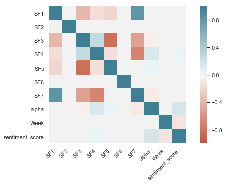

```python
GetCorrelationPlot(trainFactors_Week_df)
```

#### The negative correlation is due to, As the week of that quater ends the whole perfomance of the stock for that quater is well noted and sentiment score decreases. The decrease in sentiment score may be due to less tweets in the end of Quater

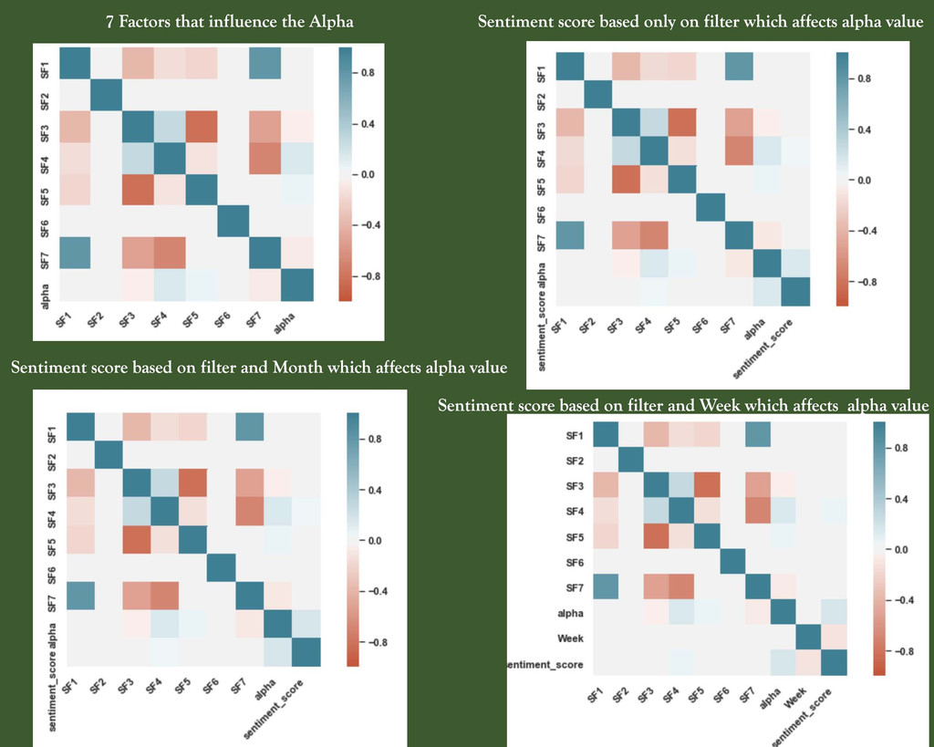

## Model Building with Sentimental score integrated to predict alpha signals:

### Reading Test,Train and wiki CSV files

```python
#Reading the CSV which consist of the 7 influential factors for the Alpha value..
trainFactors_df = pd.read_csv('train_factors-1573207730757.csv',parse_dates=[0])
testFactors_df  = pd.read_csv('test_factors.csv',parse_dates=[0])
wikiTickers_df  = pd.read_csv('secwiki_tickers.csv')
```

```python
#Getting the Train json csv file into a dataframe
Sentiment_Train_df=pd.read_json('train_data-1573118738755.json',orient='columns')
Sentiment_Train_df=pd.read_json( (Sentiment_Train_df['records']).to_json(),orient='index')
Sentiment_Test_df = pd.read_csv('ScoreSubmission_df.csv',parse_dates=[0])
```

```python
Sentiment_Train_df.head()
```

|  | sentiment_score | stocktwit_tweet | ticker | timestamp |
| --- | --- | --- | --- | --- |
| 0 | 3 | $AMD going up but hesitating however chart is very stable and going upward | $AMD | 2018-09-19 18:38:28 |
| 1 | 3 | @inforlong @MariaGascon Despite\nChina trade war $CAT held very well 👍 | $CAT | 2018-10-09 03:51:06 |
| 2 | 2 | $AVGO WTF? | $AVGO | 2018-07-12 13:35:32 |
| 3 | 2 | $PH\n New Insider Filing On: \n MULLER KLAUS PETER\nTransaction Code: \n http://www.filingscanner.com/Alerts/PH.php | $PH | 2018-07-19 03:32:50 |
| 4 | 3 | $FB if it bounces tommorrow do the right thing and GTFO | $FB | 2018-08-23 19:07:54 |

```python
Sentiment_Test_df.head()
```

|  | timestamp | ticker | sentiment_score |
| --- | --- | --- | --- |
| 0 | 2018-01-07 00:01:00 | $TDG | 4 |
| 1 | 2018-01-07 00:09:00 | $SNPS | 0 |
| 2 | 2018-01-07 00:12:00 | $NFLX | 3 |
| 3 | 2018-01-07 00:30:00 | $URI | 0 |
| 4 | 2018-01-07 00:32:00 | $K | 2 |

```python
merge_Train_df = Sentiment_Train_df[['timestamp','ticker','sentiment_score']]
```

```python
merge_Test_df = Sentiment_Test_df
```

#### Categorizing the sentiment score into Positive, Negative and Neutral sentiment.

```python
def GetSentiment(score):
    sentiment = 'Neutral'
    if score>2:
        sentiment = 'Positive'
    elif score<2:
        sentiment = 'Negative'
    elif score==2:
        sentiment = 'Neutral'
    return sentiment
```

```python
merge_Train_df['Sentiment'] = [GetSentiment(score) for score in merge_Train_df.sentiment_score]
merge_Test_df['Sentiment'] = [GetSentiment(score) for score in merge_Test_df.sentiment_score]
```

```python
merge_Train_df['Sentiment'] = merge_Train_df['Sentiment'].astype('category')
merge_Test_df['Sentiment']  = merge_Test_df['Sentiment'].astype('category')
```

### Finding the Sentiment mode for each ticker:

```python
merge_ProtoTrain_df = copy.deepcopy(merge_Train_df)
merge_ProtoTest_df = copy.deepcopy(merge_Test_df)
```

```python
merge_ProtoTrain_df = merge_ProtoTrain_df.groupby('ticker')['Sentiment'].apply(lambda x: x.mode())
merge_ProtoTest_df = merge_ProtoTest_df.groupby('ticker')['Sentiment'].apply(lambda x: x.mode())
```

```python
merge_ProtoTrain_df = pd.DataFrame(merge_ProtoTrain_df.reset_index())
merge_ProtoTest_df = pd.DataFrame(merge_ProtoTest_df.reset_index())
```

```python
merge_ProtoTest_df.head()
```

|  | ticker | level_1 | Sentiment |
| --- | --- | --- | --- |
| 0 | $$DIS | 0 | Neutral |
| 1 | $$NKE | 0 | Neutral |
| 2 | $$aapl | 0 | Neutral |
| 3 | $$amzn | 0 | Negative |
| 4 | $$s | 0 | Neutral |

```python
merge_ProtoTrain_df.drop('level_1',axis = 1, inplace= True)
merge_ProtoTest_df.drop('level_1',axis = 1, inplace= True)
```

### Merge dataframe created. Sentiment Score is avg based on weekly data:

```python
merge_Train_df['Week'] = merge_Train_df['timestamp'].dt.week
merge_Test_df['Week'] = merge_Test_df['timestamp'].dt.week
```

```python
merge_Train_df = pd.DataFrame(merge_Train_df.groupby(['ticker','Week'])['sentiment_score'].mean())
merge_Train_df = merge_Train_df.reset_index()

merge_Test_df = pd.DataFrame(merge_Test_df.groupby(['ticker','Week'])['sentiment_score'].mean())
merge_Test_df = merge_Test_df.reset_index()
```

```python
trainFactors_df.head()
```

|  | Id | date | ticker | SF1 | SF2 | SF3 | SF4 | SF5 | SF6 | SF7 | alpha |
| --- | --- | --- | --- | --- | --- | --- | --- | --- | --- | --- | --- |
| 0 | 1 | 21/08/18 | $NTAP | -0.628652 | 0.988891 | -0.055714 | 0.774379 | 0.551089 | -1.329229 | -0.995539 | 2 |
| 1 | 2 | 11/10/18 | $WYNN | 1.315786 | 1.438754 | 0.187327 | 0.608933 | -1.153030 | 1.859441 | 0.730995 | 3 |
| 2 | 3 | 21/08/18 | $DRI | -1.141388 | -1.455016 | 0.332755 | 0.674502 | 0.111326 | -0.478597 | -1.488157 | 1 |
| 3 | 4 | 10/07/18 | $ge | -0.054839 | -1.454149 | -0.162267 | -0.681870 | 0.307869 | -0.529987 | 0.404172 | 2 |
| 4 | 5 | 12/09/18 | $FE | -0.686366 | 0.838865 | 0.073830 | 0.679024 | 0.329463 | 1.262782 | -1.024042 | 2 |

```python
testFactors_df.head()
```

|  | Id | date | ticker | SF1 | SF2 | SF3 | SF4 | SF5 | SF6 | SF7 |
| --- | --- | --- | --- | --- | --- | --- | --- | --- | --- | --- |
| 0 | 270007 | 21/07/18 | $INTC | -3.062194 | 1.223466 | 1.741714 | 2.279266 | -1.323573 | -0.274912 | -4.504449 |
| 1 | 270008 | 05/10/18 | $CTSH | 0.816263 | -2.184408 | 0.157975 | -0.264743 | -0.836282 | 0.046276 | 0.826353 |
| 2 | 270009 | 01/10/18 | $CB | 0.401281 | 0.091604 | 0.083411 | -1.147041 | -0.485223 | -0.601060 | 1.012811 |
| 3 | 270010 | 24/10/18 | $CTAS | -0.783521 | 1.192929 | 0.813831 | -0.368166 | -1.113656 | -0.553581 | -0.683803 |
| 4 | 270011 | 27/07/18 | $intc | 0.796507 | 0.455341 | 0.679032 | 0.354336 | -1.799055 | 0.126153 | 0.297111 |

```python
wikiTickers_df.head()
```

|  | Ticker | Name | Sector | Industry | Price | Collection |
| --- | --- | --- | --- | --- | --- | --- |
| 0 | A | Agilent Technologies Inc. | Healthcare | Medical Laboratories & Research | WIKI/A | stocks/a |
| 1 | AA | Alcoa Inc. | Basic Materials | Aluminum | WIKI/AA | stocks/aa |
| 2 | AAME | Atlantic American Corp. | Financial | Life Insurance | NaN | stocks/aame |
| 3 | AAN | Aaron's, Inc. | Services | Rental & Leasing Services | WIKI/AAN | stocks/aan |
| 4 | AAON | AAON Inc. | Industrial Goods | General Building Materials | WIKI/AAON | stocks/aaon |

```python
print("Shape Train Factors is = ",trainFactors_df.shape)
print("Shape Test Factors  is = ",testFactors_df.shape)
print("Shape Wiki Tickers  is = ",wikiTickers_df.shape)
```

```
Shape Train Factors is =  (27006, 11)
Shape Test Factors  is =  (11575, 10)
Shape Wiki Tickers  is =  (3339, 6)
```

### Five number Summary:

```python
trainFactors_df.describe()
```

|  | SF1 | SF2 | SF3 | SF4 | SF5 | SF6 | SF7 | alpha |
| --- | --- | --- | --- | --- | --- | --- | --- | --- |
| count | 27006.000000 | 27006.000000 | 27006.000000 | 27006.000000 | 27006.000000 | 27006.000000 | 27006.000000 | 27006.000000 |
| mean | 0.005429 | -0.001005 | -0.024421 | -0.042420 | 0.041465 | 0.002597 | 0.036744 | 2.379582 |
| std | 0.941853 | 0.996130 | 0.539555 | 1.111309 | 0.976028 | 0.998839 | 1.204473 | 1.008681 |
| min | -4.114670 | -4.578587 | -2.609150 | -6.329798 | -5.480268 | -4.338751 | -5.347869 | 1.000000 |
| 25% | -0.596792 | -0.666310 | -0.300187 | -0.767247 | -0.518641 | -0.668027 | -0.688198 | 2.000000 |
| 50% | 0.012104 | -0.013257 | -0.040786 | -0.058629 | 0.072127 | 0.007417 | 0.081374 | 2.000000 |
| 75% | 0.611574 | 0.669094 | 0.241424 | 0.677433 | 0.616538 | 0.674592 | 0.807556 | 3.000000 |
| max | 4.415048 | 3.822270 | 3.452486 | 4.907407 | 4.779911 | 4.075428 | 5.182912 | 4.000000 |

#### Almost 50 % of the stock has an alpha value of 2 and rest are near equally distributed.

```python
print("The unique Tickers in Train factors are = ",len(trainFactors_df.ticker.unique()))
print("The unique Tickers in Test factors are = ",len(testFactors_df.ticker.unique()))
```

```
The unique Tickers in Train factors are =  1304
The unique Tickers in Test factors are =  1012
```

### Type casting for both Train and Test data

```python
print(trainFactors_df.dtypes)
print("---------------------------")
print(testFactors_df.dtypes)
```

```
Id         object
date       object
ticker     object
SF1       float64
SF2       float64
SF3       float64
SF4       float64
SF5       float64
SF6       float64
SF7       float64
alpha       int64
dtype: object
---------------------------
Id         object
date       object
ticker     object
SF1       float64
SF2       float64
SF3       float64
SF4       float64
SF5       float64
SF6       float64
SF7       float64
dtype: object
```

```python
# Changing data type for Train data:
trainFactors_df['Id'] = trainFactors_df['Id'].astype('category')
trainFactors_df['date'] = pd.to_datetime(trainFactors_df['date'], dayfirst = True)
trainFactors_df['ticker'] = trainFactors_df['ticker'].astype('category')
trainFactors_df['alpha'] = trainFactors_df['alpha'].astype('category')

# Changing data type for Test data:
testFactors_df['Id'] = testFactors_df['Id'].astype('category')
testFactors_df['date'] = pd.to_datetime(testFactors_df['date'], dayfirst = True)
testFactors_df['ticker'] = testFactors_df['ticker'].astype('category')

print(trainFactors_df.dtypes)
print("---------------------------")
print(testFactors_df.dtypes)
```

```
Id              category
date      datetime64[ns]
ticker          category
SF1              float64
SF2              float64
SF3              float64
SF4              float64
SF5              float64
SF6              float64
SF7              float64
alpha           category
dtype: object
---------------------------
Id              category
date      datetime64[ns]
ticker          category
SF1              float64
SF2              float64
SF3              float64
SF4              float64
SF5              float64
SF6              float64
SF7              float64
dtype: object
```

### Dropping Id attribute in both train and test because it adds no value.

```python
trainFactors_df.drop('Id',axis = 1, inplace= True)
testFactors_df.drop('Id',axis = 1, inplace= True)
```

```python
#Unique Alpha values
trainFactors_df.alpha.unique()
```

```
[2, 3, 1, 4]
Categories (4, int64): [2, 3, 1, 4]
```

### Making Month and week as separate attribute from date and dropping date attribute:

```python
trainFactors_df['Month'] = trainFactors_df['date'].dt.month_name(locale = 'English')
trainFactors_df['Week'] = trainFactors_df['date'].dt.week
trainFactors_df['Day']  = trainFactors_df['date'].dt.weekday_name
trainFactors_df.drop('date',axis = 1, inplace= True)

testFactors_df['Month'] = testFactors_df['date'].dt.month_name(locale = 'English')
testFactors_df['Week'] = testFactors_df['date'].dt.week
testFactors_df['Day']  = testFactors_df['date'].dt.weekday_name
testFactors_df.drop('date',axis = 1, inplace= True)
```

```python
trainFactors_df['Month'] = trainFactors_df['Month'].astype('category')
trainFactors_df['Week'] = trainFactors_df['Week'].astype('int64')
trainFactors_df['Day'] = trainFactors_df['Day'].astype('category')

testFactors_df['Month'] = testFactors_df['Month'].astype('category')
testFactors_df['Week'] = testFactors_df['Week'].astype('int64')
testFactors_df['Day'] = testFactors_df['Day'].astype('category')
```

```python
trainFactors_df.head()
```

|  | ticker | SF1 | SF2 | SF3 | SF4 | SF5 | SF6 | SF7 | alpha | Month | Week | Day |
| --- | --- | --- | --- | --- | --- | --- | --- | --- | --- | --- | --- | --- |
| 0 | $NTAP | -0.628652 | 0.988891 | -0.055714 | 0.774379 | 0.551089 | -1.329229 | -0.995539 | 2 | August | 34 | Tuesday |
| 1 | $WYNN | 1.315786 | 1.438754 | 0.187327 | 0.608933 | -1.153030 | 1.859441 | 0.730995 | 3 | October | 41 | Thursday |
| 2 | $DRI | -1.141388 | -1.455016 | 0.332755 | 0.674502 | 0.111326 | -0.478597 | -1.488157 | 1 | August | 34 | Tuesday |
| 3 | $ge | -0.054839 | -1.454149 | -0.162267 | -0.681870 | 0.307869 | -0.529987 | 0.404172 | 2 | July | 28 | Tuesday |
| 4 | $FE | -0.686366 | 0.838865 | 0.073830 | 0.679024 | 0.329463 | 1.262782 | -1.024042 | 2 | September | 37 | Wednesday |

```python
testFactors_df.head()
```

|  | ticker | SF1 | SF2 | SF3 | SF4 | SF5 | SF6 | SF7 | Month | Week | Day |
| --- | --- | --- | --- | --- | --- | --- | --- | --- | --- | --- | --- |
| 0 | $INTC | -3.062194 | 1.223466 | 1.741714 | 2.279266 | -1.323573 | -0.274912 | -4.504449 | July | 29 | Saturday |
| 1 | $CTSH | 0.816263 | -2.184408 | 0.157975 | -0.264743 | -0.836282 | 0.046276 | 0.826353 | October | 40 | Friday |
| 2 | $CB | 0.401281 | 0.091604 | 0.083411 | -1.147041 | -0.485223 | -0.601060 | 1.012811 | October | 40 | Monday |
| 3 | $CTAS | -0.783521 | 1.192929 | 0.813831 | -0.368166 | -1.113656 | -0.553581 | -0.683803 | October | 43 | Wednesday |
| 4 | $intc | 0.796507 | 0.455341 | 0.679032 | 0.354336 | -1.799055 | 0.126153 | 0.297111 | July | 30 | Friday |

```python
testFactors_df.shape
```

```
(11575, 11)
```

### Merging Sentiment score:

```python
trainFactors_df = pd.merge(trainFactors_df,merge_Train_df, on=['ticker','Week'],how='left')
testFactors_df = pd.merge(testFactors_df,merge_Test_df, on=['ticker','Week'],how='left')
```

```python
print("Shape Train Factors after merging is = ",trainFactors_df.shape)
print("Shape Test Factors after merging  is = ",testFactors_df.shape)
```

```
Shape Train Factors after merging is =  (27006, 13)
Shape Test Factors after merging  is =  (11575, 12)
```

```python
trainFactors_df['ticker'] = trainFactors_df['ticker'].astype('category')
testFactors_df['ticker'] = testFactors_df['ticker'].astype('category')
```

```python
trainFactors_df.head()
```

|  | ticker | SF1 | SF2 | SF3 | SF4 | SF5 | SF6 | SF7 | alpha | Month | Week | Day | sentiment_score |
| --- | --- | --- | --- | --- | --- | --- | --- | --- | --- | --- | --- | --- | --- |
| 0 | $NTAP | -0.628652 | 0.988891 | -0.055714 | 0.774379 | 0.551089 | -1.329229 | -0.995539 | 2 | August | 34 | Tuesday | 2.068966 |
| 1 | $WYNN | 1.315786 | 1.438754 | 0.187327 | 0.608933 | -1.153030 | 1.859441 | 0.730995 | 3 | October | 41 | Thursday | 2.081633 |
| 2 | $DRI | -1.141388 | -1.455016 | 0.332755 | 0.674502 | 0.111326 | -0.478597 | -1.488157 | 1 | August | 34 | Tuesday | 1.952381 |
| 3 | $ge | -0.054839 | -1.454149 | -0.162267 | -0.681870 | 0.307869 | -0.529987 | 0.404172 | 2 | July | 28 | Tuesday | 2.030303 |
| 4 | $FE | -0.686366 | 0.838865 | 0.073830 | 0.679024 | 0.329463 | 1.262782 | -1.024042 | 2 | September | 37 | Wednesday | 1.750000 |

### Adding Sector as aattribute from Wiki dataframe:

```python
def GetCleanTickerSector(ticker):
    nticker = re.sub(r'[^\w]','', ticker)
    nticker = nticker.upper()
    sectorName = ""
    sectorName = wikiTickers_df.loc[wikiTickers_df["Ticker"]==nticker,'Sector']
    sectorName = sectorName.to_string()
    sectorName = re.sub(r'[\d]','', sectorName)
    return sectorName
```

```python
trainFactors_df['Sector'] = [GetCleanTickerSector(tickerT) for tickerT in trainFactors_df.ticker]
```

```python
testFactors_df['Sector'] = [GetCleanTickerSector(tickerT) for tickerT in testFactors_df.ticker]
```

```python
# Converting the sector into type category.
trainFactors_df['Sector'] = trainFactors_df['Sector'].astype('category')

testFactors_df['Sector'] = testFactors_df['Sector'].astype('category')
```

```python
print("Shape Train Factors after Creating new Attribute is = ",trainFactors_df.shape)
print("Shape Test Factors after Creating new Attribute  is = ",testFactors_df.shape)
```

```
Shape Train Factors after Creating new Attribute is =  (27006, 14)
Shape Test Factors after Creating new Attribute  is =  (11575, 13)
```

#### Taking a deep copy of the Train and Test data.

```python
trainFactors_Processed_df = copy.deepcopy(trainFactors_df)
testFactors_Processed_df = copy.deepcopy(testFactors_df)
```

```python
# trainFactors_Processed_df.drop('SF7',axis = 1, inplace= True)
# testFactors_Processed_df.drop('SF7',axis = 1, inplace= True)

# trainFactors_Processed_df.drop('Week',axis = 1, inplace= True)
# testFactors_Processed_df.drop('Week',axis = 1, inplace= True)
```

```python
print("Shape Train Factors after Dropping Attribute is = ",trainFactors_Processed_df.shape)
print("Shape Test Factors after Dropping Attribute  is = ",testFactors_Processed_df.shape)
```

```
Shape Train Factors after Dropping Attribute is =  (27006, 14)
Shape Test Factors after Dropping Attribute  is =  (11575, 13)
```

#### Merging the Sentiment of each ticker:

```python
merge_ProtoTrain_df['ticker'] = merge_ProtoTrain_df['ticker'].astype('category')
merge_ProtoTest_df['ticker'] = merge_ProtoTest_df['ticker'].astype('category')
```

```python
merge_ProtoTrain_df.drop_duplicates(subset ="ticker",keep = False, inplace = True)
merge_ProtoTest_df.drop_duplicates(subset ="ticker",keep = False, inplace = True)
```

```python
trainFactors_Processed_df = trainFactors_Processed_df.merge(merge_ProtoTrain_df, on=['ticker'],how='left')
testFactors_Processed_df  = testFactors_Processed_df.merge(merge_ProtoTest_df, on=['ticker'],how='left')
trainFactors_Processed_df.head()
```

|  | ticker | SF1 | SF2 | SF3 | SF4 | SF5 | SF6 | SF7 | alpha | Month | Week | Day | sentiment_score | Sector | Sentiment |
| --- | --- | --- | --- | --- | --- | --- | --- | --- | --- | --- | --- | --- | --- | --- | --- |
| 0 | $NTAP | -0.628652 | 0.988891 | -0.055714 | 0.774379 | 0.551089 | -1.329229 | -0.995539 | 2 | August | 34 | Tuesday | 2.068966 | Technology | Neutral |
| 1 | $WYNN | 1.315786 | 1.438754 | 0.187327 | 0.608933 | -1.153030 | 1.859441 | 0.730995 | 3 | October | 41 | Thursday | 2.081633 | Services | Neutral |
| 2 | $DRI | -1.141388 | -1.455016 | 0.332755 | 0.674502 | 0.111326 | -0.478597 | -1.488157 | 1 | August | 34 | Tuesday | 1.952381 | Services | Neutral |
| 3 | $ge | -0.054839 | -1.454149 | -0.162267 | -0.681870 | 0.307869 | -0.529987 | 0.404172 | 2 | July | 28 | Tuesday | 2.030303 | Industrial Goods | Neutral |
| 4 | $FE | -0.686366 | 0.838865 | 0.073830 | 0.679024 | 0.329463 | 1.262782 | -1.024042 | 2 | September | 37 | Wednesday | 1.750000 | Utilities | Neutral |

```python
trainFactors_Processed_df['ticker'] = trainFactors_Processed_df['ticker'].astype('category')
testFactors_Processed_df['ticker'] = testFactors_Processed_df['ticker'].astype('category')
```

```python
print("Shape Train Factors after Merging Sentiment is = ",trainFactors_Processed_df.shape)
print("Shape Test Factors after Merging Sentiment  is = ",testFactors_Processed_df.shape)
```

```
Shape Train Factors after Merging Sentiment is =  (27006, 15)
Shape Test Factors after Merging Sentiment  is =  (11575, 14)
```

#### Checking the Data distribution of all seven factors influencing alpha

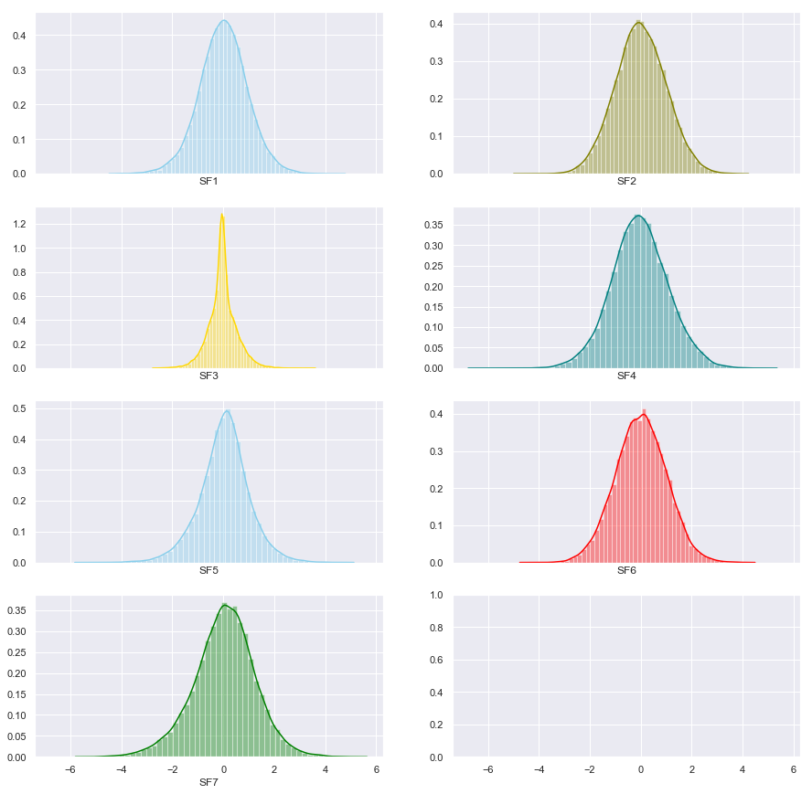

```python
f, axes = plt.subplots(4, 2, figsize=(15,15), sharex=True)
sns.distplot(trainFactors_Processed_df["SF1"].dropna() , color="skyblue", ax=axes[0, 0])
sns.distplot( trainFactors_Processed_df["SF2"].dropna() , color="olive", ax=axes[0, 1])
sns.distplot( trainFactors_Processed_df['SF3'].dropna() , color="gold", ax=axes[1, 0])
sns.distplot( trainFactors_Processed_df['SF4'].dropna() , color="teal", ax=axes[1, 1])
sns.distplot( trainFactors_Processed_df['SF5'].dropna() , color="skyblue", ax=axes[2, 0])
sns.distplot( trainFactors_Processed_df['SF6'].dropna() , color="Red", ax=axes[2, 1])
sns.distplot( trainFactors_Processed_df['SF7'].dropna() , color="Green", ax=axes[3, 0])
plt.savefig('pr1')
```

```python
# sns.distplot(trainFactors_Processed_df["sentiment_score"].dropna())
trainFactors_Processed_df.dtypes
```

```
ticker             category
SF1                 float64
SF2                 float64
SF3                 float64
SF4                 float64
SF5                 float64
SF6                 float64
SF7                 float64
alpha              category
Month              category
Week                  int64
Day                category
sentiment_score     float64
Sector             category
Sentiment          category
dtype: object
```

### Train and Test Split

```python
from sklearn.model_selection import train_test_split
trainFactors_Processed_df["alpha"] = trainFactors_Processed_df["alpha"].astype('category')
```

```python
Y = trainFactors_Processed_df["alpha"]
X = trainFactors_Processed_df.drop('alpha', axis=1)
X_train, X_test, Y_train, Y_test = train_test_split(X, Y, test_size=0.20,random_state=123)
```

```python
print(X_train.shape)
print(X_test.shape)
print(Y_train.shape)
print(Y_test.shape)
```

```
(21604, 14)
(5402, 14)
(21604,)
(5402,)
```

```python
trainFactors_Processed_df['ticker'] = trainFactors_Processed_df['ticker'].astype('category')
testFactors_Processed_df['ticker'] = testFactors_Processed_df['ticker'].astype('category')
```

```python
trainFactors_Processed_df.isnull().sum()
```

```
ticker               0
SF1                  0
SF2                  0
SF3                  0
SF4                  0
SF5                  0
SF6                  0
SF7                  0
alpha                0
Month                0
Week                 0
Day                  0
sentiment_score    498
Sector               0
Sentiment          193
dtype: int64
```

```python
testFactors_Processed_df.isnull().sum()
```

```
ticker               0
SF1                  0
SF2                  0
SF3                  0
SF4                  0
SF5                  0
SF6                  0
SF7                  0
Month                0
Week                 0
Day                  0
sentiment_score    876
Sector               0
Sentiment           24
dtype: int64
```

### Split Numerical and Categorical variables

```python
numAttributes = X_train.select_dtypes(['int64','float64']).columns
catAttributes = X_train.select_dtypes('category').columns
```

```python
numAttributes_unseen = testFactors_Processed_df.select_dtypes(['int64','float64']).columns
catAttributes_unseen = testFactors_Processed_df.select_dtypes('category').columns
```

```python
print(numAttributes)
print(catAttributes)
```

```
Index(['SF1', 'SF2', 'SF3', 'SF4', 'SF5', 'SF6', 'SF7', 'Week',
       'sentiment_score'],
      dtype='object')
Index(['ticker', 'Month', 'Day', 'Sector', 'Sentiment'], dtype='object')
```

```python
print(numAttributes_unseen)
print(catAttributes_unseen)
```

```
Index(['SF1', 'SF2', 'SF3', 'SF4', 'SF5', 'SF6', 'SF7', 'Week',
       'sentiment_score'],
      dtype='object')
Index(['ticker', 'Month', 'Day', 'Sector', 'Sentiment'], dtype='object')
```

#### Imputing Numeric Attributes:

```python
imputer = SimpleImputer(strategy='median')
imputer = imputer.fit(X_train[numAttributes])

X_train[numAttributes] = imputer.transform(X_train[numAttributes])
X_test[numAttributes] = imputer.transform(X_test[numAttributes])
testFactors_Processed_df[numAttributes_unseen] = imputer.transform(testFactors_Processed_df[numAttributes_unseen])
```

#### Imputing Categorical attributes:

```python
imputer = SimpleImputer(strategy='most_frequent')
imputer = imputer.fit(X_train[catAttributes])

X_train[catAttributes] = imputer.transform(X_train[catAttributes])
X_test[catAttributes] = imputer.transform(X_test[catAttributes])
testFactors_Processed_df[catAttributes_unseen] = imputer.transform(testFactors_Processed_df[catAttributes_unseen])
```

#### Standardizing the Numerical columns of Train and Test

```python
scaler = StandardScaler()

scaler.fit(X_train[numAttributes])

X_train[numAttributes]=scaler.transform(X_train[numAttributes])
X_test[numAttributes]=scaler.transform(X_test[numAttributes])
testFactors_Processed_df[numAttributes_unseen]=scaler.transform(testFactors_Processed_df[numAttributes_unseen])
```

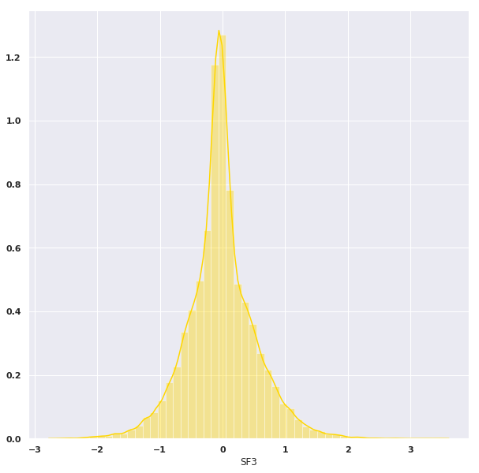

```python
sns.distplot( trainFactors_Processed_df['SF3'].dropna() , color="gold")
```

#### Performing Dummification for categorical variables

```python
# X_train = pd.get_dummies(columns=catAttributes,data=X_train,drop_first=True)
# X_test = pd.get_dummies(columns=catAttributes,data=X_test,drop_first=True)
```

##### Label Encoding

```python
#Import label encoder
from sklearn import preprocessing
from sklearn.preprocessing import OneHotEncoder
```

```python
# label_encoder object knows how to understand word labels.
label_encoder = preprocessing.LabelEncoder()
```

```python
X_train.head()
```

|  | ticker | SF1 | SF2 | SF3 | SF4 | SF5 | SF6 | SF7 | Month | Week | Day | sentiment_score | Sector | Sentiment |
| --- | --- | --- | --- | --- | --- | --- | --- | --- | --- | --- | --- | --- | --- | --- |
| 21477 | $fb | 0.747055 | 0.435764 | -0.494819 | -2.363322 | -0.087905 | 0.726232 | 1.875005 | August | -0.042846 | Thursday | 2.048789 | Technology | Neutral |
| 16190 | $ba | 0.503281 | 0.840391 | 0.174011 | -1.065091 | -0.567979 | -0.863855 | 0.910406 | August | -0.240209 | Wednesday | -0.264281 | Industrial Goods | Neutral |
| 5698 | $PLD | 0.159238 | 2.871696 | -1.138177 | -0.924809 | 1.062687 | -0.363051 | 0.758069 | October | 0.943972 | Tuesday | -0.400535 | Series([], ) | Neutral |
| 23385 | $ATVI | 0.740889 | -1.719840 | 0.262537 | 0.310970 | -0.710712 | 0.984525 | 0.302660 | August | -0.832300 | Wednesday | 0.716601 | Technology | Positive |
| 14472 | $ABT | -1.791616 | -0.942727 | 1.213076 | 0.118697 | -0.208227 | 0.489027 | -1.437917 | October | 1.141336 | Friday | 1.101750 | Healthcare | Neutral |

```python
# Encode labels in column 'species'.
X_train['ticker'] = label_encoder.fit_transform(X_train['ticker'])
X_train['Month'] = label_encoder.fit_transform(X_train['Month'])
X_train['Day'] = label_encoder.fit_transform(X_train['Day'])
X_train['Sector'] = label_encoder.fit_transform(X_train['Sector'])
X_train['Sentiment'] = label_encoder.fit_transform(X_train['Sentiment'])

X_test['ticker'] = label_encoder.fit_transform(X_test['ticker'])
X_test['Month'] = label_encoder.fit_transform(X_test['Month'])
X_test['Day'] = label_encoder.fit_transform(X_test['Day'])
X_test['Sector'] = label_encoder.fit_transform(X_test['Sector'])
X_test['Sentiment'] = label_encoder.fit_transform(X_test['Sentiment'])


# Label encoding on unseen data
testFactors_Processed_df['ticker'] = label_encoder.fit_transform(testFactors_Processed_df['ticker'])
testFactors_Processed_df['Month'] = label_encoder.fit_transform(testFactors_Processed_df['Month'])
testFactors_Processed_df['Day'] = label_encoder.fit_transform(testFactors_Processed_df['Day'])
testFactors_Processed_df['Sector'] = label_encoder.fit_transform(testFactors_Processed_df['Sector'])
testFactors_Processed_df['Sentiment'] = label_encoder.fit_transform(testFactors_Processed_df['Sentiment'])
```